# contig_lengths

Desirrê Petters-Vandresen

01/11/2022

# Contig lengths thresholds (for Circos plots)

### Background

When producing the Circos plots for some of the *Phyllosticta* genome assemblies, some of the plots were too cluttered, as the assemblies were more fragmented and some of the contigs/scaffolds were too small to be properly depicted in the figure. The idea for the updated Circos plots (the ones included in the final version of the manuscript) is to create some sort of threshold for the contigs that will be included in the plot, excluding contigs that are too small. However, as they will be excluded from the plot, there was the need to somehow show that they do not represent to much information from the genome.

Hence, the need to produce some distribution plots to evaluate and assess how many contigs/scaffolds can be removed without removing important genomic information from plot.

To be more flexible with customization and manually setting the threshold, I refrained from creating a loop (which makes this a very long Markdown file, but there’s a version of this script with an implemented for loop in the file [“contig_lengths_with_for_loop.Rmd”](https://github.com/desirrepetters/phyllosticta-genome-architecture/blob/main/contig_lengths.R/contig_lengths_with_for_loop.Rmd)).

### Packages

```r
library(seqinr)
library(tidyverse)
library(scales)
library(wesanderson)
```

### Getting the assemblies

To run this code, I first created symbolic links for the genome files in the workdir (the files were stored in another computer folder):

```r
file.symlink(from="../../Documentos/Genomes/Phyllosticta/PCapitalensis_CBS173_77.fasta", to=".")
```

```
## [1] TRUE
```

```r
file.symlink(from="../../Documentos/Genomes/Phyllosticta/PCapitalensis_CBS356_52.fasta", to=".")
```

```
## [1] TRUE
```

```r
file.symlink(from="../../Documentos/Genomes/Phyllosticta/PCapitalensis_CBS111638.fasta", to=".")
```

```
## [1] TRUE
```

```r
file.symlink(from="../../Documentos/Genomes/Phyllosticta/PCapitalensis_CBS117118.fasta", to=".")
```

```
## [1] TRUE
```

```r
file.symlink(from="../../Documentos/Genomes/Phyllosticta/PCapitalensis_CBS123374.fasta", to=".")
```

```
## [1] TRUE
```

```r
file.symlink(from="../../Documentos/Genomes/Phyllosticta/PCapitalensis_CBS128856.fasta", to=".")
```

```
## [1] TRUE
```

```r
file.symlink(from="../../Documentos/Genomes/Phyllosticta/PCapitalensis_LGMF01.fasta", to=".")
```

```
## [1] TRUE
```

```r
file.symlink(from="../../Documentos/Genomes/Phyllosticta/PCitriasiana_CBS120486.fasta", to=".")
```

```
## [1] TRUE
```

```r
file.symlink(from="../../Documentos/Genomes/Phyllosticta/PCitriasiana_CBS120426.fasta", to=".")
```

```
## [1] TRUE
```

```r
file.symlink(from="../../Documentos/Genomes/Phyllosticta/PCitriasiana_CBS123371.fasta", to=".")
```

```
## [1] TRUE
```

```r
file.symlink(from="../../Documentos/Genomes/Phyllosticta/PCitriasiana_CGMCC314344.fasta", to=".")
```

```
## [1] TRUE
```

```r
file.symlink(from="../../Documentos/Genomes/Phyllosticta/PCitribraziliensis_CBS100098.fasta", to=".")
```

```
## [1] TRUE
```

```r
file.symlink(from="../../Documentos/Genomes/Phyllosticta/PCitribraziliensis_LGMF08.fasta", to=".")
```

```
## [1] TRUE
```

```r
file.symlink(from="../../Documentos/Genomes/Phyllosticta/PCitribraziliensis_CPC17464.fasta", to=".")
```

```
## [1] TRUE
```

```r
file.symlink(from="../../Documentos/Genomes/Phyllosticta/PCitricarpa_CBS111_20.fasta", to=".")
```

```
## [1] TRUE
```

```r
file.symlink(from="../../Documentos/Genomes/Phyllosticta/PCitricarpa_CBS102373.fasta", to=".")
```

```
## [1] TRUE
```

```r
file.symlink(from="../../Documentos/Genomes/Phyllosticta/PCitricarpa_CBS122482.fasta", to=".")
```

```
## [1] TRUE
```

```r
file.symlink(from="../../Documentos/Genomes/Phyllosticta/PCitricarpa_CBS122670.fasta", to=".")
```

```
## [1] TRUE
```

```r
file.symlink(from="../../Documentos/Genomes/Phyllosticta/PCitricarpa_CBS127454.fasta", to=".")
```

```
## [1] TRUE
```

```r
file.symlink(from="../../Documentos/Genomes/Phyllosticta/PCitricarpa_CBS131864.fasta", to=".")
```

```
## [1] TRUE
```

```r
file.symlink(from="../../Documentos/Genomes/Phyllosticta/PCitricarpa_CBS141352.fasta", to=".")
```

```
## [1] TRUE
```

```r
file.symlink(from="../../Documentos/Genomes/Phyllosticta/PCitricarpa_CPC16586.fasta", to=".")
```

```
## [1] TRUE
```

```r
file.symlink(from="../../Documentos/Genomes/Phyllosticta/PCitricarpa_CPC27913.fasta", to=".")
```

```
## [1] TRUE
```

```r
file.symlink(from="../../Documentos/Genomes/Phyllosticta/PCitrichinaensis_CBS129764.fasta", to=".")
```

```
## [1] TRUE
```

```r
file.symlink(from="../../Documentos/Genomes/Phyllosticta/PCitrichinaensis_CBS130529.fasta", to=".")
```

```
## [1] TRUE
```

```r
file.symlink(from="../../Documentos/Genomes/Phyllosticta/PParacitricarpa_CPC27169.fasta", to=".")
```

```
## [1] TRUE
```

```r
file.symlink(from="../../Documentos/Genomes/Phyllosticta/PParacitricarpa_CBS141358.fasta", to=".")
```

```
## [1] TRUE
```

```r
file.symlink(from="../../Documentos/Genomes/Pseudofusicoccum/Pseudofusicoccum_sp_LGMF1611.fasta", to=".")
```

```
## [1] TRUE
```

### Avoiding the use of scientific notation in the plot

Without avoind the use of scientific notation, genome size was a little confusing on the y axis of the plot.

```r
options(scipen=5)
```

# *Phyllosticta capitalensis*

```r
dir.create("PCapitalensis")
```

## *Phyllosticta capitalensis* CBS 128856

Reading data

```r
# Read scaffold/contig lengths with read.fasta from seqinr
PCapitalensis_CBS128856_fasta <- read.fasta("PCapitalensis_CBS128856.fasta")
PCapitalensis_CBS128856_lengths <- getLength(PCapitalensis_CBS128856_fasta)

#Length sum, percentage of total length, cumulative sum
PCapitalensis_CBS128856_length_sum <- sum(PCapitalensis_CBS128856_lengths)
PCapitalensis_CBS128856_perc <- PCapitalensis_CBS128856_lengths/PCapitalensis_CBS128856_length_sum
PCapitalensis_CBS128856_length_cumsum <- cumsum(PCapitalensis_CBS128856_lengths)
PCapitalensis_CBS128856_perc_cumsum <- cumsum(PCapitalensis_CBS128856_perc)

#Creating a data frame for ggplot
PCapitalensis_CBS128856_df <- data.frame(PCapitalensis_CBS128856_lengths, PCapitalensis_CBS128856_perc)
```

Plotting cumulative sum of lengths and saving image

```r
# Adjusting colour palette according to number of contigs
PCapitalensis_CBS128856_colours <- c(wes_palette("Zissou1", length(PCapitalensis_CBS128856_lengths), type="continuous"))

PCapitalensis_CBS128856_length_title <- paste("Cumulative length of scaffolds vs. cumulative number of scaffolds for \n", "P. capitalensis CBS 128856 \n")

PCapitalensis_CBS128856_length_plot <-
  ggplot(PCapitalensis_CBS128856_df,
         aes(x=1:length(PCapitalensis_CBS128856_length_cumsum),
             y=PCapitalensis_CBS128856_length_cumsum)) +
  geom_point(aes(size=PCapitalensis_CBS128856_lengths, color = PCapitalensis_CBS128856_lengths)) +
  scale_size_continuous(name = "Scaffold size (bp)\n", breaks = fivenum(PCapitalensis_CBS128856_df$PCapitalensis_CBS128856_lengths), labels = comma(fivenum(PCapitalensis_CBS128856_df$PCapitalensis_CBS128856_lengths))) +
  geom_vline(xintercept=14, linetype="dashed", color = "red") +
  scale_color_continuous(low = head(PCapitalensis_CBS128856_colours), high = tail(PCapitalensis_CBS128856_colours), name = "Scaffold size (bp)\n", guide = "legend", breaks = fivenum(PCapitalensis_CBS128856_df$PCapitalensis_CBS128856_lengths), labels = comma(fivenum(PCapitalensis_CBS128856_df$PCapitalensis_CBS128856_lengths))) + geom_line(color="#046C9A")

## Final plot

PCapitalensis_CBS128856_final_plot <-
  PCapitalensis_CBS128856_length_plot +
  ggtitle(PCapitalensis_CBS128856_length_title) +
  xlab("\nCumulative number of scaffolds") +
  ylab("Cumulative length of scaffolds (bp) \n") +
  theme(plot.title = element_text(hjust = 0.5)) +
   scale_y_continuous(label=comma)

png("./PCapitalensis/PCapitalensis_CBS128856.png")
  PCapitalensis_CBS128856_final_plot
dev.off()
```

```r
pdf("./PCapitalensis/PCapitalensis_CBS128856.pdf")
  PCapitalensis_CBS128856_final_plot
dev.off()
```

```r
svg("./PCapitalensis/PCapitalensis_CBS128856.svg")
  PCapitalensis_CBS128856_final_plot
dev.off()
```

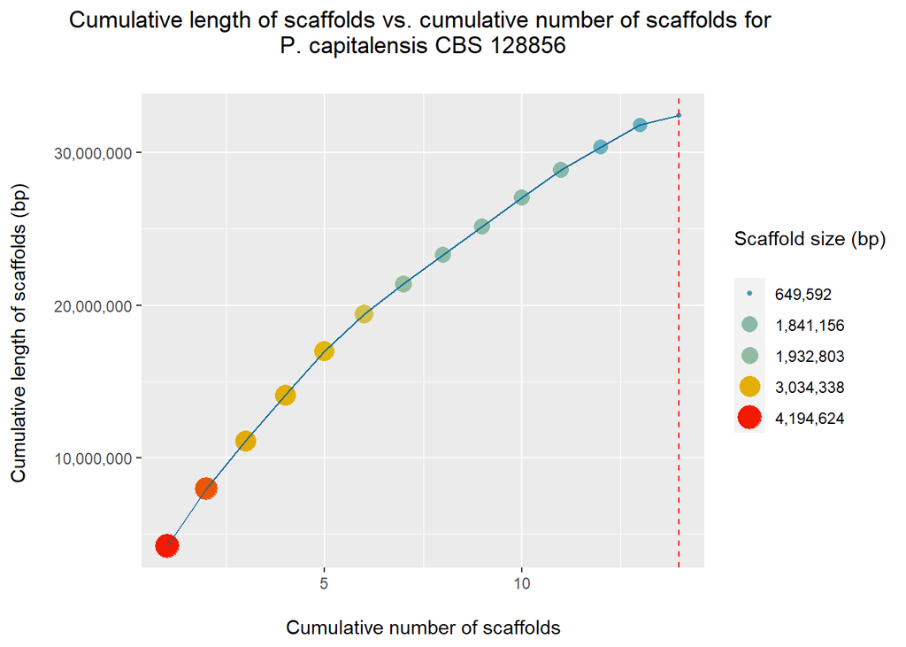

```r
PCapitalensis_CBS128856_final_plot
```

## *Phyllosticta capitalensis* CBS 173.77

Reading data

```r
# Read scaffold/contig lengths with read.fasta from seqinr
PCapitalensis_CBS173_77_fasta <- read.fasta("PCapitalensis_CBS173_77.fasta")
PCapitalensis_CBS173_77_lengths <- getLength(PCapitalensis_CBS173_77_fasta)

#Length sum, percentage of total length, cumulative sum
PCapitalensis_CBS173_77_length_sum <- sum(PCapitalensis_CBS173_77_lengths)
PCapitalensis_CBS173_77_perc <- PCapitalensis_CBS173_77_lengths/PCapitalensis_CBS173_77_length_sum
PCapitalensis_CBS173_77_length_cumsum <- cumsum(PCapitalensis_CBS173_77_lengths)
PCapitalensis_CBS173_77_perc_cumsum <- cumsum(PCapitalensis_CBS173_77_perc)

#Creating a data frame for ggplot
PCapitalensis_CBS173_77_df <- data.frame(PCapitalensis_CBS173_77_lengths, PCapitalensis_CBS173_77_perc)
```

Plotting cumulative sum of lengths and saving image

```r
# Adjusting colour palette according to number of contigs
PCapitalensis_CBS173_77_colours <- c(wes_palette("Zissou1", length(PCapitalensis_CBS173_77_lengths), type="continuous"))

PCapitalensis_CBS173_77_length_title <- paste("Cumulative length of scaffolds vs. cumulative number of scaffolds for \n", "P. capitalensis CBS 173.77 \n")

PCapitalensis_CBS173_77_length_plot <-
  ggplot(PCapitalensis_CBS173_77_df,
         aes(x=1:length(PCapitalensis_CBS173_77_length_cumsum),
             y=PCapitalensis_CBS173_77_length_cumsum)) +
  geom_point(aes(size=PCapitalensis_CBS173_77_lengths, color = PCapitalensis_CBS173_77_lengths)) +
  scale_size_continuous(name = "Scaffold size (bp)\n", breaks = fivenum(PCapitalensis_CBS173_77_df$PCapitalensis_CBS173_77_lengths), labels = comma(fivenum(PCapitalensis_CBS173_77_df$PCapitalensis_CBS173_77_lengths))) +
  geom_vline(xintercept=15, linetype="dashed", color = "red") +
  scale_color_continuous(low = head(PCapitalensis_CBS173_77_colours), high = tail(PCapitalensis_CBS173_77_colours), name = "Scaffold size (bp)\n", guide = "legend", breaks = fivenum(PCapitalensis_CBS173_77_df$PCapitalensis_CBS173_77_lengths), labels = comma(fivenum(PCapitalensis_CBS173_77_df$PCapitalensis_CBS173_77_lengths))) + geom_line(color="#046C9A")

## Final plot

PCapitalensis_CBS173_77_final_plot <-
  PCapitalensis_CBS173_77_length_plot +
  ggtitle(PCapitalensis_CBS173_77_length_title) +
  xlab("\nCumulative number of scaffolds") +
  ylab("Cumulative length of scaffolds (bp) \n") +
  theme(plot.title = element_text(hjust = 0.5)) +
   scale_y_continuous(label=comma)

png("./PCapitalensis/PCapitalensis_CBS173_77.png")
  PCapitalensis_CBS173_77_final_plot
dev.off()
```

```r
pdf("./PCapitalensis/PCapitalensis_CBS173_77.pdf")
  PCapitalensis_CBS173_77_final_plot
dev.off()
```

```r
svg("./PCapitalensis/PCapitalensis_CBS173_77.svg")
  PCapitalensis_CBS173_77_final_plot
dev.off()
```

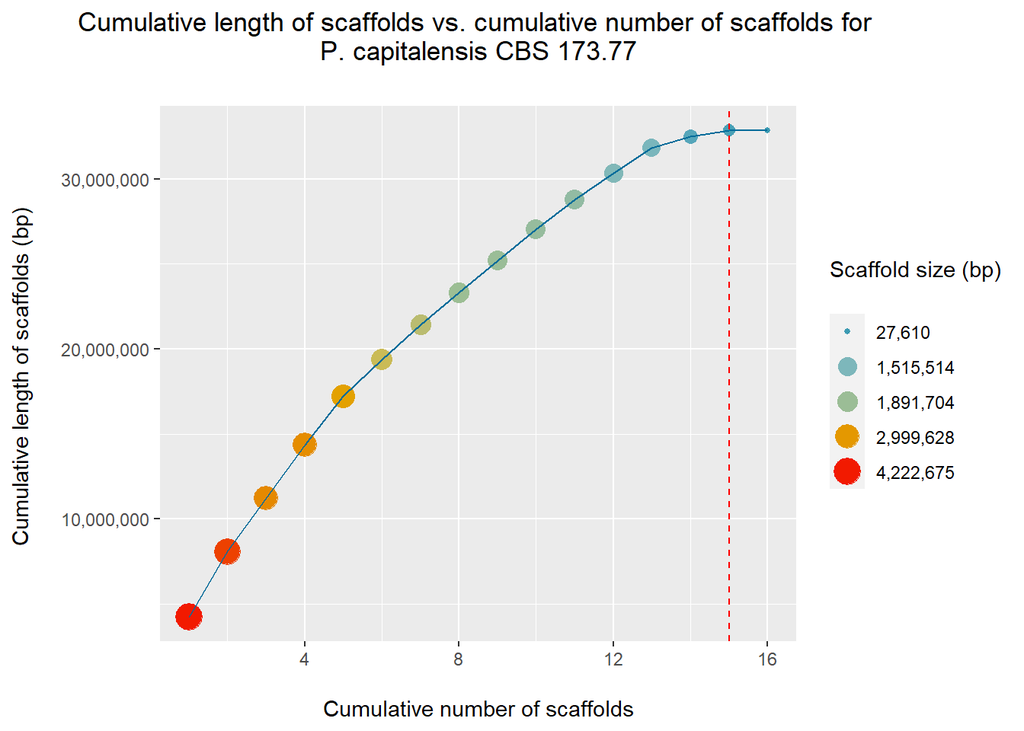

```r
PCapitalensis_CBS173_77_final_plot
```

## *Phyllosticta capitalensis* CBS 356.52

Reading data

```r
# Read scaffold/contig lengths with read.fasta from seqinr
PCapitalensis_CBS356_52_fasta <- read.fasta("PCapitalensis_CBS356_52.fasta")
PCapitalensis_CBS356_52_lengths <- getLength(PCapitalensis_CBS356_52_fasta)

#Length sum, percentage of total length, cumulative sum
PCapitalensis_CBS356_52_length_sum <- sum(PCapitalensis_CBS356_52_lengths)
PCapitalensis_CBS356_52_perc <- PCapitalensis_CBS356_52_lengths/PCapitalensis_CBS356_52_length_sum
PCapitalensis_CBS356_52_length_cumsum <- cumsum(PCapitalensis_CBS356_52_lengths)
PCapitalensis_CBS356_52_perc_cumsum <- cumsum(PCapitalensis_CBS356_52_perc)

#Creating a data frame for ggplot
PCapitalensis_CBS356_52_df <- data.frame(PCapitalensis_CBS356_52_lengths, PCapitalensis_CBS356_52_perc)
```

Plotting cumulative sum of lengths and saving image

```r
# Adjusting colour palette according to number of contigs
PCapitalensis_CBS356_52_colours <- c(wes_palette("Zissou1", length(PCapitalensis_CBS356_52_lengths), type="continuous"))

PCapitalensis_CBS356_52_length_title <- paste("Cumulative length of scaffolds vs. cumulative number of scaffolds for \n", "P. capitalensis CBS 356.52 \n")

PCapitalensis_CBS356_52_length_plot <-
  ggplot(PCapitalensis_CBS356_52_df,
         aes(x=1:length(PCapitalensis_CBS356_52_length_cumsum),
             y=PCapitalensis_CBS356_52_length_cumsum)) +
  geom_point(aes(size=PCapitalensis_CBS356_52_lengths, color = PCapitalensis_CBS356_52_lengths)) +
  scale_size_continuous(name = "Scaffold size (bp)\n", breaks = fivenum(PCapitalensis_CBS356_52_df$PCapitalensis_CBS356_52_lengths), labels = comma(fivenum(PCapitalensis_CBS356_52_df$PCapitalensis_CBS356_52_lengths))) +
  geom_vline(xintercept=16, linetype="dashed", color = "red") +
  scale_color_continuous(low = head(PCapitalensis_CBS356_52_colours), high = tail(PCapitalensis_CBS356_52_colours), name = "Scaffold size (bp)\n", guide = "legend", breaks = fivenum(PCapitalensis_CBS356_52_df$PCapitalensis_CBS356_52_lengths), labels = comma(fivenum(PCapitalensis_CBS356_52_df$PCapitalensis_CBS356_52_lengths))) + geom_line(color="#046C9A")

## Final plot

PCapitalensis_CBS356_52_final_plot <-
  PCapitalensis_CBS356_52_length_plot +
  ggtitle(PCapitalensis_CBS356_52_length_title) +
  xlab("\nCumulative number of scaffolds") +
  ylab("Cumulative length of scaffolds (bp) \n") +
  theme(plot.title = element_text(hjust = 0.5)) +
   scale_y_continuous(label=comma)

png("./PCapitalensis/PCapitalensis_CBS356_52.png")
  PCapitalensis_CBS356_52_final_plot
dev.off()
```

```r
pdf("./PCapitalensis/PCapitalensis_CBS356_52.pdf")
  PCapitalensis_CBS356_52_final_plot
dev.off()
```

```r
svg("./PCapitalensis/PCapitalensis_CBS356_52.svg")
  PCapitalensis_CBS356_52_final_plot
dev.off()
```

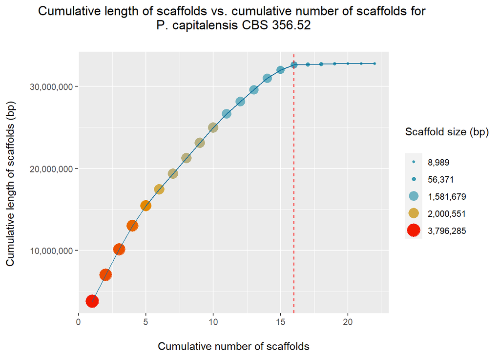

```r
PCapitalensis_CBS356_52_final_plot
```

## *Phyllosticta capitalensis* CBS 111638

Reading data

```r
# Read scaffold/contig lengths with read.fasta from seqinr
PCapitalensis_CBS111638_fasta <- read.fasta("PCapitalensis_CBS111638.fasta")
PCapitalensis_CBS111638_lengths <- getLength(PCapitalensis_CBS111638_fasta)

#Length sum, percentage of total length, cumulative sum
PCapitalensis_CBS111638_length_sum <- sum(PCapitalensis_CBS111638_lengths)
PCapitalensis_CBS111638_perc <- PCapitalensis_CBS111638_lengths/PCapitalensis_CBS111638_length_sum
PCapitalensis_CBS111638_length_cumsum <- cumsum(PCapitalensis_CBS111638_lengths)
PCapitalensis_CBS111638_perc_cumsum <- cumsum(PCapitalensis_CBS111638_perc)

#Creating a data frame for ggplot
PCapitalensis_CBS111638_df <- data.frame(PCapitalensis_CBS111638_lengths, PCapitalensis_CBS111638_perc)
```

Plotting cumulative sum of lengths and saving image

```r
# Adjusting colour palette according to number of contigs
PCapitalensis_CBS111638_colours <- c(wes_palette("Zissou1", length(PCapitalensis_CBS111638_lengths), type="continuous"))

PCapitalensis_CBS111638_length_title <- paste("Cumulative length of scaffolds vs. cumulative number of scaffolds for \n", "P. capitalensis CBS 111638 \n")

PCapitalensis_CBS111638_length_plot <-
  ggplot(PCapitalensis_CBS111638_df,
         aes(x=1:length(PCapitalensis_CBS111638_length_cumsum),
             y=PCapitalensis_CBS111638_length_cumsum)) +
  geom_point(aes(size=PCapitalensis_CBS111638_lengths, color = PCapitalensis_CBS111638_lengths)) +
  scale_size_continuous(name = "Scaffold size (bp)\n", breaks = fivenum(PCapitalensis_CBS111638_df$PCapitalensis_CBS111638_lengths), labels = comma(fivenum(PCapitalensis_CBS111638_df$PCapitalensis_CBS111638_lengths))) +
  geom_vline(xintercept=16, linetype="dashed", color = "red") +
  scale_color_continuous(low = head(PCapitalensis_CBS111638_colours), high = tail(PCapitalensis_CBS111638_colours), name = "Scaffold size (bp)\n", guide = "legend", breaks = fivenum(PCapitalensis_CBS111638_df$PCapitalensis_CBS111638_lengths), labels = comma(fivenum(PCapitalensis_CBS111638_df$PCapitalensis_CBS111638_lengths))) + geom_line(color="#046C9A")

## Final plot

PCapitalensis_CBS111638_final_plot <-
  PCapitalensis_CBS111638_length_plot +
  ggtitle(PCapitalensis_CBS111638_length_title) +
  xlab("\nCumulative number of scaffolds") +
  ylab("Cumulative length of scaffolds (bp) \n") +
  theme(plot.title = element_text(hjust = 0.5)) +
   scale_y_continuous(label=comma)

png("./PCapitalensis/PCapitalensis_CBS111638.png")
  PCapitalensis_CBS111638_final_plot
dev.off()
```

```r
pdf("./PCapitalensis/PCapitalensis_CBS111638.pdf")
  PCapitalensis_CBS111638_final_plot
dev.off()
```

```r
svg("./PCapitalensis/PCapitalensis_CBS111638.svg")
  PCapitalensis_CBS111638_final_plot
dev.off()
```

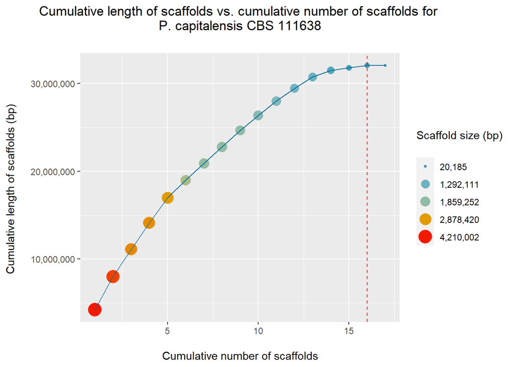

```r
PCapitalensis_CBS111638_final_plot
```

## *Phyllosticta capitalensis* CBS 117118

Reading data

```r
# Read scaffold/contig lengths with read.fasta from seqinr
PCapitalensis_CBS117118_fasta <- read.fasta("PCapitalensis_CBS117118.fasta")
PCapitalensis_CBS117118_lengths <- getLength(PCapitalensis_CBS117118_fasta)

#Length sum, percentage of total length, cumulative sum
PCapitalensis_CBS117118_length_sum <- sum(PCapitalensis_CBS117118_lengths)
PCapitalensis_CBS117118_perc <- PCapitalensis_CBS117118_lengths/PCapitalensis_CBS117118_length_sum
PCapitalensis_CBS117118_length_cumsum <- cumsum(PCapitalensis_CBS117118_lengths)
PCapitalensis_CBS117118_perc_cumsum <- cumsum(PCapitalensis_CBS117118_perc)

#Creating a data frame for ggplot
PCapitalensis_CBS117118_df <- data.frame(PCapitalensis_CBS117118_lengths, PCapitalensis_CBS117118_perc)
```

Plotting cumulative sum of lengths and saving image

```r
# Adjusting colour palette according to number of contigs
PCapitalensis_CBS117118_colours <- c(wes_palette("Zissou1", length(PCapitalensis_CBS117118_lengths), type="continuous"))

PCapitalensis_CBS117118_length_title <- paste("Cumulative length of scaffolds vs. cumulative number of scaffolds for \n", "P. capitalensis CBS 117118 \n")

PCapitalensis_CBS117118_length_plot <-
  ggplot(PCapitalensis_CBS117118_df,
         aes(x=1:length(PCapitalensis_CBS117118_length_cumsum),
             y=PCapitalensis_CBS117118_length_cumsum)) +
  geom_point(aes(size=PCapitalensis_CBS117118_lengths, color = PCapitalensis_CBS117118_lengths)) +
  scale_size_continuous(name = "Scaffold size (bp)\n", breaks = fivenum(PCapitalensis_CBS117118_df$PCapitalensis_CBS117118_lengths), labels = comma(fivenum(PCapitalensis_CBS117118_df$PCapitalensis_CBS117118_lengths))) +
  geom_vline(xintercept=16, linetype="dashed", color = "red") +
  scale_color_continuous(low = head(PCapitalensis_CBS117118_colours), high = tail(PCapitalensis_CBS117118_colours), name = "Scaffold size (bp)\n", guide = "legend", breaks = fivenum(PCapitalensis_CBS117118_df$PCapitalensis_CBS117118_lengths), labels = comma(fivenum(PCapitalensis_CBS117118_df$PCapitalensis_CBS117118_lengths))) + geom_line(color="#046C9A")

## Final plot

PCapitalensis_CBS117118_final_plot <-
  PCapitalensis_CBS117118_length_plot +
  ggtitle(PCapitalensis_CBS117118_length_title) +
  xlab("\nCumulative number of scaffolds") +
  ylab("Cumulative length of scaffolds (bp) \n") +
  theme(plot.title = element_text(hjust = 0.5)) +
   scale_y_continuous(label=comma)

png("./PCapitalensis/PCapitalensis_CBS117118.png")
  PCapitalensis_CBS117118_final_plot
dev.off()
```

```r
pdf("./PCapitalensis/PCapitalensis_CBS117118.pdf")
  PCapitalensis_CBS117118_final_plot
dev.off()
```

```r
svg("./PCapitalensis/PCapitalensis_CBS117118.svg")
  PCapitalensis_CBS117118_final_plot
dev.off()
```

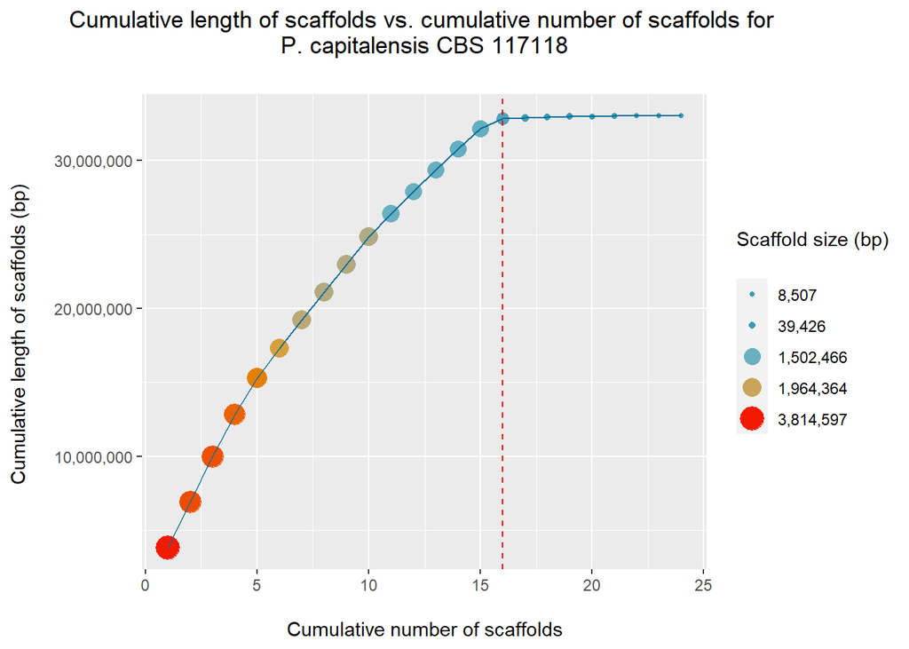

```r
PCapitalensis_CBS117118_final_plot
```

## *Phyllosticta capitalensis* CBS 123374

Reading data

```r
# Read scaffold/contig lengths with read.fasta from seqinr
PCapitalensis_CBS123374_fasta <- read.fasta("PCapitalensis_CBS123374.fasta")
PCapitalensis_CBS123374_lengths <- getLength(PCapitalensis_CBS123374_fasta)

#Length sum, percentage of total length, cumulative sum
PCapitalensis_CBS123374_length_sum <- sum(PCapitalensis_CBS123374_lengths)
PCapitalensis_CBS123374_perc <- PCapitalensis_CBS123374_lengths/PCapitalensis_CBS123374_length_sum
PCapitalensis_CBS123374_length_cumsum <- cumsum(PCapitalensis_CBS123374_lengths)
PCapitalensis_CBS123374_perc_cumsum <- cumsum(PCapitalensis_CBS123374_perc)

#Creating a data frame for ggplot
PCapitalensis_CBS123374_df <- data.frame(PCapitalensis_CBS123374_lengths, PCapitalensis_CBS123374_perc)
```

Plotting cumulative sum of lengths and saving image

```r
# Adjusting colour palette according to number of contigs
PCapitalensis_CBS123374_colours <- c(wes_palette("Zissou1", length(PCapitalensis_CBS123374_lengths), type="continuous"))

PCapitalensis_CBS123374_length_title <- paste("Cumulative length of scaffolds vs. cumulative number of scaffolds for \n", "P. capitalensis CBS 123374 \n")

PCapitalensis_CBS123374_length_plot <-
  ggplot(PCapitalensis_CBS123374_df,
         aes(x=1:length(PCapitalensis_CBS123374_length_cumsum),
             y=PCapitalensis_CBS123374_length_cumsum)) +
  geom_point(aes(size=PCapitalensis_CBS123374_lengths, color = PCapitalensis_CBS123374_lengths)) +
  scale_size_continuous(name = "Scaffold size (bp)\n", breaks = fivenum(PCapitalensis_CBS123374_df$PCapitalensis_CBS123374_lengths), labels = comma(fivenum(PCapitalensis_CBS123374_df$PCapitalensis_CBS123374_lengths))) +
  geom_vline(xintercept=15, linetype="dashed", color = "red") +
  scale_color_continuous(low = head(PCapitalensis_CBS123374_colours), high = tail(PCapitalensis_CBS123374_colours), name = "Scaffold size (bp)\n", guide = "legend", breaks = fivenum(PCapitalensis_CBS123374_df$PCapitalensis_CBS123374_lengths), labels = comma(fivenum(PCapitalensis_CBS123374_df$PCapitalensis_CBS123374_lengths))) +   geom_line(color="#046C9A")

## Final plot

PCapitalensis_CBS123374_final_plot <-
  PCapitalensis_CBS123374_length_plot +
  ggtitle(PCapitalensis_CBS123374_length_title) +
  xlab("\nCumulative number of scaffolds") +
  ylab("Cumulative length of scaffolds (bp) \n") +
  theme(plot.title = element_text(hjust = 0.5)) +
   scale_y_continuous(label=comma)

png("./PCapitalensis/PCapitalensis_CBS123374.png")
  PCapitalensis_CBS123374_final_plot
dev.off()
```

```r
pdf("./PCapitalensis/PCapitalensis_CBS123374.pdf")
  PCapitalensis_CBS123374_final_plot
dev.off()
```

```r
svg("./PCapitalensis/PCapitalensis_CBS123374.svg")
  PCapitalensis_CBS123374_final_plot
dev.off()
```

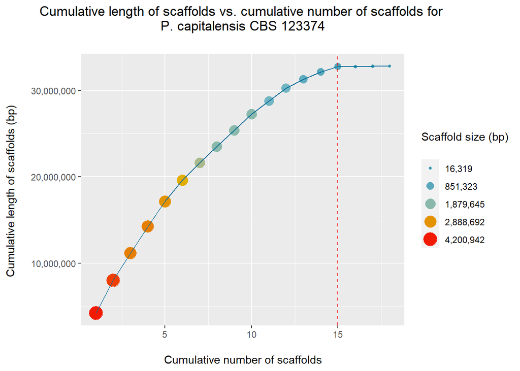

```r
PCapitalensis_CBS123374_final_plot
```

## *Phyllosticta capitalensis* LGMF01

Reading data

```r
# Read scaffold/contig lengths with read.fasta from seqinr
PCapitalensis_LGMF01_fasta <- read.fasta("PCapitalensis_LGMF01.fasta")
PCapitalensis_LGMF01_lengths <- sort(getLength(PCapitalensis_LGMF01_fasta), decreasing=TRUE)

#Length sum, percentage of total length, cumulative sum
PCapitalensis_LGMF01_length_sum <- sum(PCapitalensis_LGMF01_lengths)
PCapitalensis_LGMF01_perc <- PCapitalensis_LGMF01_lengths/PCapitalensis_LGMF01_length_sum
PCapitalensis_LGMF01_length_cumsum <- cumsum(PCapitalensis_LGMF01_lengths)
PCapitalensis_LGMF01_perc_cumsum <- cumsum(PCapitalensis_LGMF01_perc)

#Creating a data frame for ggplot
PCapitalensis_LGMF01_df <- data.frame(PCapitalensis_LGMF01_lengths, PCapitalensis_LGMF01_perc)
```

Plotting cumulative sum of lengths and saving image

```r
# Adjusting colour palette according to number of contigs
PCapitalensis_LGMF01_colours <- c(wes_palette("Zissou1", length(PCapitalensis_LGMF01_lengths)/10, type="continuous"))

PCapitalensis_LGMF01_length_title <- paste("Cumulative length of scaffolds vs. cumulative number of scaffolds for \n", "P. capitalensis LGMF 01 \n")

PCapitalensis_LGMF01_length_plot <-
  ggplot(PCapitalensis_LGMF01_df,
         aes(x=1:length(PCapitalensis_LGMF01_length_cumsum),
             y=PCapitalensis_LGMF01_length_cumsum)) +
  geom_point(aes(size=PCapitalensis_LGMF01_lengths, color = PCapitalensis_LGMF01_lengths)) +
  scale_size_continuous(name = "Scaffold size (bp)\n", breaks = fivenum(PCapitalensis_LGMF01_df$PCapitalensis_LGMF01_lengths), labels = comma(fivenum(PCapitalensis_LGMF01_df$PCapitalensis_LGMF01_lengths))) +
  geom_vline(xintercept=33, linetype="dashed", color = "red") +
  scale_color_continuous(low = head(PCapitalensis_LGMF01_colours), high = tail(PCapitalensis_LGMF01_colours), name = "Scaffold size (bp)\n", guide = "legend", breaks = fivenum(PCapitalensis_LGMF01_df$PCapitalensis_LGMF01_lengths), labels = comma(fivenum(PCapitalensis_LGMF01_df$PCapitalensis_LGMF01_lengths))) +
  geom_line(color="#046C9A")

## Final plot

PCapitalensis_LGMF01_final_plot <-
  PCapitalensis_LGMF01_length_plot +
  ggtitle(PCapitalensis_LGMF01_length_title) +
  xlab("\nCumulative number of scaffolds") +
  ylab("Cumulative length of scaffolds (bp) \n") +
  theme(plot.title = element_text(hjust = 0.5)) +
   scale_y_continuous(label=comma)

png("./PCapitalensis/PCapitalensis_LGMF01.png")
  PCapitalensis_LGMF01_final_plot
dev.off()
```

```r
pdf("./PCapitalensis/PCapitalensis_LGMF01.pdf")
  PCapitalensis_LGMF01_final_plot
dev.off()
```

```r
svg("./PCapitalensis/PCapitalensis_LGMF01.svg")
  PCapitalensis_LGMF01_final_plot
dev.off()
```

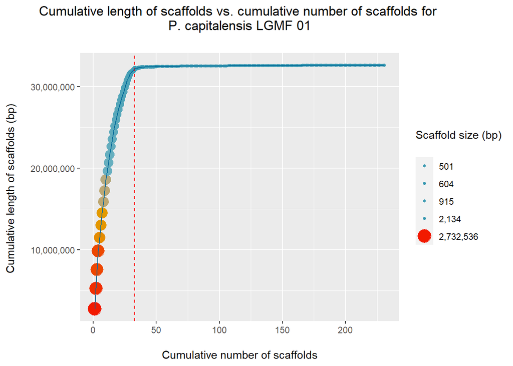

```r
PCapitalensis_LGMF01_final_plot
```

# *Phyllosticta citriasiana*

```r
dir.create("PCitriasiana")
```

## *Phyllosticta citriasiana* CBS 120486

Reading data

```r
# Read scaffold/contig lengths with read.fasta from seqinr
PCitriasiana_CBS120486_fasta <- read.fasta("PCitriasiana_CBS120486.fasta")
PCitriasiana_CBS120486_lengths <- sort(getLength(PCitriasiana_CBS120486_fasta), decreasing=TRUE)

#Length sum, percentage of total length, cumulative sum
PCitriasiana_CBS120486_length_sum <- sum(PCitriasiana_CBS120486_lengths)
PCitriasiana_CBS120486_perc <- PCitriasiana_CBS120486_lengths/PCitriasiana_CBS120486_length_sum
PCitriasiana_CBS120486_length_cumsum <- cumsum(PCitriasiana_CBS120486_lengths)
PCitriasiana_CBS120486_perc_cumsum <- cumsum(PCitriasiana_CBS120486_perc)

#Creating a data frame for ggplot
PCitriasiana_CBS120486_df <- data.frame(PCitriasiana_CBS120486_lengths, PCitriasiana_CBS120486_perc)
```

Plotting cumulative sum of lengths and saving image

```r
# Adjusting colour palette according to number of contigs
PCitriasiana_CBS120486_colours <- c(wes_palette("Zissou1", length(PCitriasiana_CBS120486_lengths)/10, type="continuous"))

PCitriasiana_CBS120486_length_title <- paste("Cumulative length of scaffolds vs. cumulative number of scaffolds for \n", "P. citriasiana CBS 120486 \n")

PCitriasiana_CBS120486_length_plot <-
  ggplot(PCitriasiana_CBS120486_df,
         aes(x=1:length(PCitriasiana_CBS120486_length_cumsum),
             y=PCitriasiana_CBS120486_length_cumsum)) +
  geom_point(aes(size=PCitriasiana_CBS120486_lengths, color = PCitriasiana_CBS120486_lengths)) +
  scale_size_continuous(name = "Scaffold size (bp)\n", breaks = fivenum(PCitriasiana_CBS120486_df$PCitriasiana_CBS120486_lengths), labels = comma(fivenum(PCitriasiana_CBS120486_df$PCitriasiana_CBS120486_lengths))) +
  geom_vline(xintercept=40, linetype="dashed", color = "red") +
  scale_color_continuous(low = head(PCitriasiana_CBS120486_colours), high = tail(PCitriasiana_CBS120486_colours), name = "Scaffold size (bp)\n", guide = "legend", breaks = fivenum(PCitriasiana_CBS120486_df$PCitriasiana_CBS120486_lengths), labels = comma(fivenum(PCitriasiana_CBS120486_df$PCitriasiana_CBS120486_lengths))) + geom_line(color="#046C9A")

## Final plot

PCitriasiana_CBS120486_final_plot <-
  PCitriasiana_CBS120486_length_plot +
  ggtitle(PCitriasiana_CBS120486_length_title) +
  xlab("\nCumulative number of scaffolds") +
  ylab("Cumulative length of scaffolds (bp) \n") +
  theme(plot.title = element_text(hjust = 0.5)) +
   scale_y_continuous(label=comma)

png("./PCitriasiana/PCitriasiana_CBS120486.png")
  PCitriasiana_CBS120486_final_plot
dev.off()
```

```r
pdf("./PCitriasiana/PCitriasiana_CBS120486.pdf")
  PCitriasiana_CBS120486_final_plot
dev.off()
```

```r
svg("./PCitriasiana/PCitriasiana_CBS120486.svg")
  PCitriasiana_CBS120486_final_plot
dev.off()
```

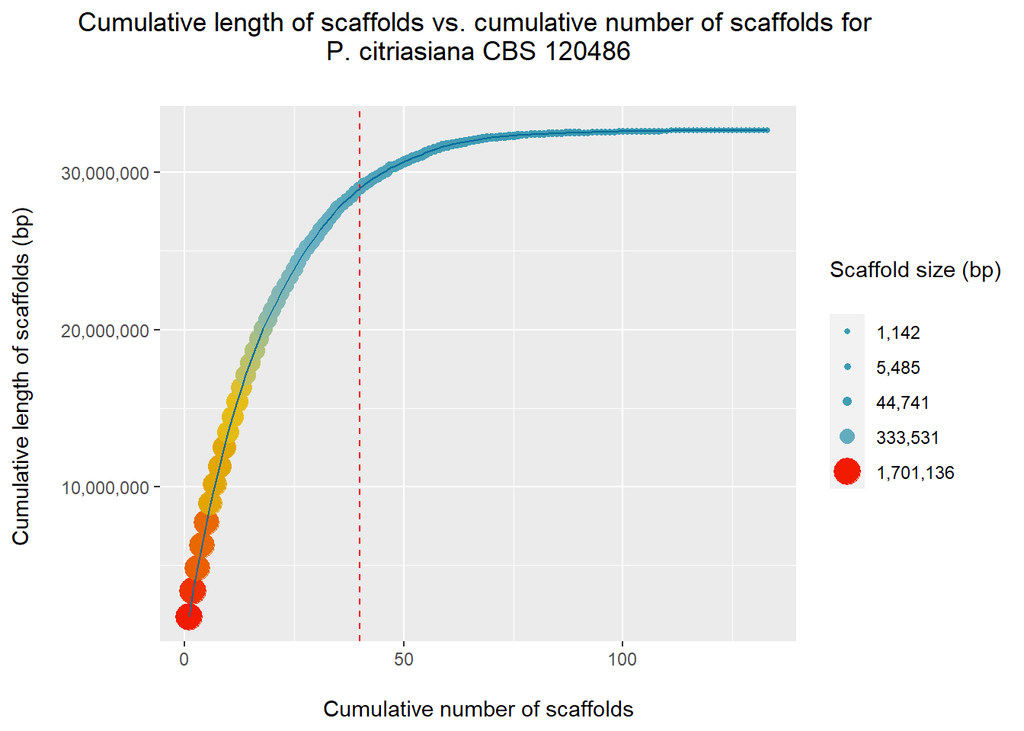

```r
PCitriasiana_CBS120486_final_plot
```

## *Phyllosticta citriasiana* CBS 120426

Reading data

```r
# Read scaffold/contig lengths with read.fasta from seqinr
PCitriasiana_CBS120426_fasta <- read.fasta("PCitriasiana_CBS120426.fasta")
PCitriasiana_CBS120426_lengths <- sort(getLength(PCitriasiana_CBS120426_fasta), decreasing=TRUE)

#Length sum, percentage of total length, cumulative sum
PCitriasiana_CBS120426_length_sum <- sum(PCitriasiana_CBS120426_lengths)
PCitriasiana_CBS120426_perc <- PCitriasiana_CBS120426_lengths/PCitriasiana_CBS120426_length_sum
PCitriasiana_CBS120426_length_cumsum <- cumsum(PCitriasiana_CBS120426_lengths)
PCitriasiana_CBS120426_perc_cumsum <- cumsum(PCitriasiana_CBS120426_perc)

#Creating a data frame for ggplot
PCitriasiana_CBS120426_df <- data.frame(PCitriasiana_CBS120426_lengths, PCitriasiana_CBS120426_perc)
```

Plotting cumulative sum of lengths and saving image

```r
# Adjusting colour palette according to number of contigs
PCitriasiana_CBS120426_colours <- c(wes_palette("Zissou1", length(PCitriasiana_CBS120426_lengths)/10, type="continuous"))

PCitriasiana_CBS120426_length_title <- paste("Cumulative length of scaffolds vs. cumulative number of scaffolds for \n", "P. citriasiana CBS 120426 \n")

PCitriasiana_CBS120426_length_plot <-
  ggplot(PCitriasiana_CBS120426_df,
         aes(x=1:length(PCitriasiana_CBS120426_length_cumsum),
             y=PCitriasiana_CBS120426_length_cumsum)) +
  geom_point(aes(size=PCitriasiana_CBS120426_lengths, color = PCitriasiana_CBS120426_lengths)) +
  scale_size_continuous(name = "Scaffold size (bp)\n", breaks = fivenum(PCitriasiana_CBS120426_df$PCitriasiana_CBS120426_lengths), labels = comma(fivenum(PCitriasiana_CBS120426_df$PCitriasiana_CBS120426_lengths))) +
  geom_vline(xintercept=30, linetype="dashed", color = "red") +
  scale_color_continuous(low = head(PCitriasiana_CBS120426_colours), high = tail(PCitriasiana_CBS120426_colours), name = "Scaffold size (bp)\n", guide = "legend", breaks = fivenum(PCitriasiana_CBS120426_df$PCitriasiana_CBS120426_lengths), labels = comma(fivenum(PCitriasiana_CBS120426_df$PCitriasiana_CBS120426_lengths))) + geom_line(color="#046C9A")

## Final plot

PCitriasiana_CBS120426_final_plot <-
  PCitriasiana_CBS120426_length_plot +
  ggtitle(PCitriasiana_CBS120426_length_title) +
  xlab("\nCumulative number of scaffolds") +
  ylab("Cumulative length of scaffolds (bp) \n") +
  theme(plot.title = element_text(hjust = 0.5)) +
   scale_y_continuous(label=comma)

png("./PCitriasiana/PCitriasiana_CBS120426.png")
  PCitriasiana_CBS120426_final_plot
dev.off()
```

```r
pdf("./PCitriasiana/PCitriasiana_CBS120426.pdf")
  PCitriasiana_CBS120426_final_plot
dev.off()
```

```r
svg("./PCitriasiana/PCitriasiana_CBS120426.svg")
  PCitriasiana_CBS120426_final_plot
dev.off()
```

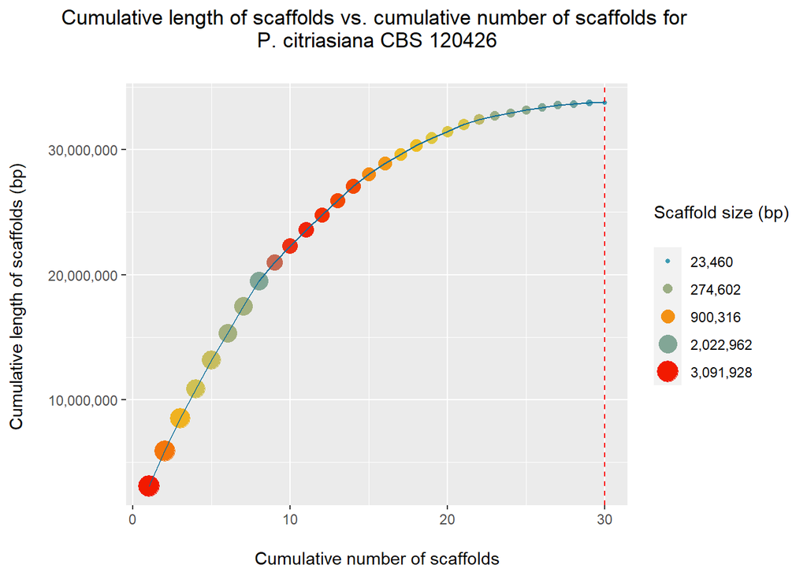

```r
PCitriasiana_CBS120426_final_plot
```

## *Phyllosticta citriasiana* CBS 123371

Reading data

```r
# Read scaffold/contig lengths with read.fasta from seqinr
PCitriasiana_CBS123371_fasta <- read.fasta("PCitriasiana_CBS123371.fasta")
PCitriasiana_CBS123371_lengths <- sort(getLength(PCitriasiana_CBS123371_fasta), decreasing=TRUE)

#Length sum, percentage of total length, cumulative sum
PCitriasiana_CBS123371_length_sum <- sum(PCitriasiana_CBS123371_lengths)
PCitriasiana_CBS123371_perc <- PCitriasiana_CBS123371_lengths/PCitriasiana_CBS123371_length_sum
PCitriasiana_CBS123371_length_cumsum <- cumsum(PCitriasiana_CBS123371_lengths)
PCitriasiana_CBS123371_perc_cumsum <- cumsum(PCitriasiana_CBS123371_perc)

#Creating a data frame for ggplot
PCitriasiana_CBS123371_df <- data.frame(PCitriasiana_CBS123371_lengths, PCitriasiana_CBS123371_perc)
```

Plotting cumulative sum of lengths and saving image

```r
# Adjusting colour palette according to number of contigs
PCitriasiana_CBS123371_colours <- c(wes_palette("Zissou1", length(PCitriasiana_CBS123371_lengths)/10, type="continuous"))

PCitriasiana_CBS123371_length_title <- paste("Cumulative length of scaffolds vs. cumulative number of scaffolds for \n", "P. citriasiana CBS 123371 \n")

PCitriasiana_CBS123371_length_plot <-
  ggplot(PCitriasiana_CBS123371_df,
         aes(x=1:length(PCitriasiana_CBS123371_length_cumsum),
             y=PCitriasiana_CBS123371_length_cumsum)) +
  geom_point(aes(size=PCitriasiana_CBS123371_lengths, color = PCitriasiana_CBS123371_lengths)) +
  scale_size_continuous(name = "Scaffold size (bp)\n", breaks = fivenum(PCitriasiana_CBS123371_df$PCitriasiana_CBS123371_lengths), labels = comma(fivenum(PCitriasiana_CBS123371_df$PCitriasiana_CBS123371_lengths))) +
  geom_vline(xintercept=26, linetype="dashed", color = "red") +
  scale_color_continuous(low = head(PCitriasiana_CBS123371_colours), high = tail(PCitriasiana_CBS123371_colours), name = "Scaffold size (bp)\n", guide = "legend", breaks = fivenum(PCitriasiana_CBS123371_df$PCitriasiana_CBS123371_lengths), labels = comma(fivenum(PCitriasiana_CBS123371_df$PCitriasiana_CBS123371_lengths))) + geom_line(color="#046C9A")

## Final plot

PCitriasiana_CBS123371_final_plot <-
  PCitriasiana_CBS123371_length_plot +
  ggtitle(PCitriasiana_CBS123371_length_title) +
  xlab("\nCumulative number of scaffolds") +
  ylab("Cumulative length of scaffolds (bp) \n") +
  theme(plot.title = element_text(hjust = 0.5)) +
   scale_y_continuous(label=comma)

png("./PCitriasiana/PCitriasiana_CBS123371.png")
  PCitriasiana_CBS123371_final_plot
dev.off()
```

```r
pdf("./PCitriasiana/PCitriasiana_CBS123371.pdf")
  PCitriasiana_CBS123371_final_plot
dev.off()
```

```r
svg("./PCitriasiana/PCitriasiana_CBS123371.svg")
  PCitriasiana_CBS123371_final_plot
dev.off()
```

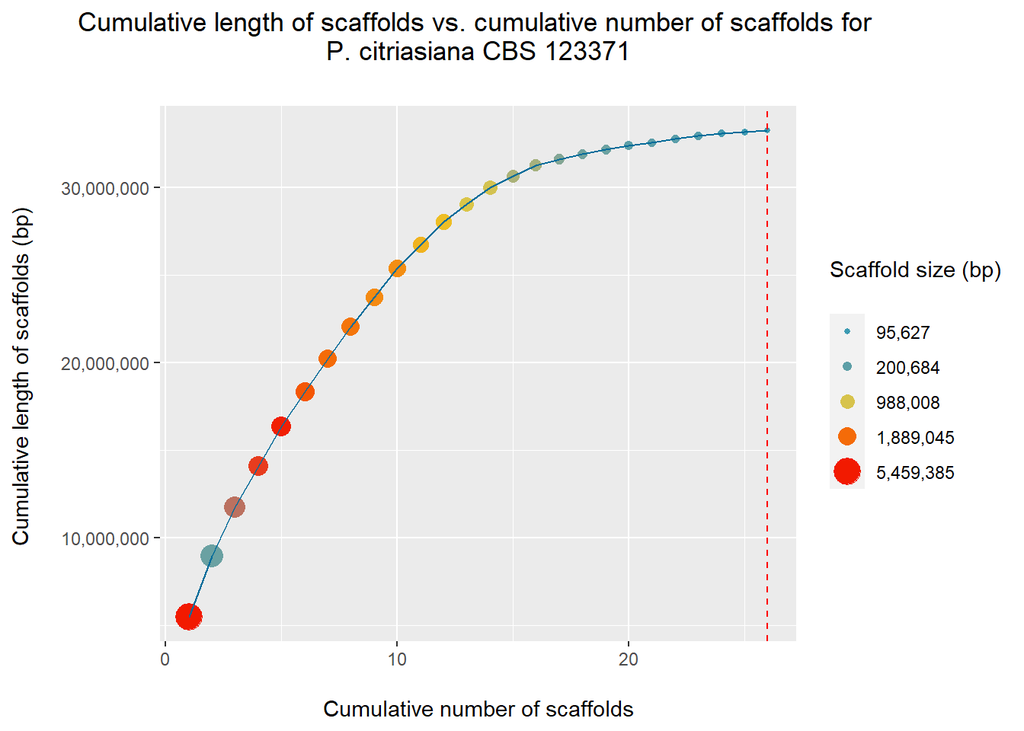

```r
PCitriasiana_CBS123371_final_plot
```

## *Phyllosticta citriasiana* CGMCC 3.14344

Reading data

```r
# Read scaffold/contig lengths with read.fasta from seqinr
PCitriasiana_CGMCC314344_fasta <- read.fasta("PCitriasiana_CGMCC314344.fasta")
PCitriasiana_CGMCC314344_lengths <- sort(getLength(PCitriasiana_CGMCC314344_fasta), decreasing=TRUE)

#Length sum, percentage of total length, cumulative sum
PCitriasiana_CGMCC314344_length_sum <- sum(PCitriasiana_CGMCC314344_lengths)
PCitriasiana_CGMCC314344_perc <- PCitriasiana_CGMCC314344_lengths/PCitriasiana_CGMCC314344_length_sum
PCitriasiana_CGMCC314344_length_cumsum <- cumsum(PCitriasiana_CGMCC314344_lengths)
PCitriasiana_CGMCC314344_perc_cumsum <- cumsum(PCitriasiana_CGMCC314344_perc)

#Creating a data frame for ggplot
PCitriasiana_CGMCC314344_df <- data.frame(PCitriasiana_CGMCC314344_lengths, PCitriasiana_CGMCC314344_perc)
```

Plotting cumulative sum of lengths and saving image

```r
# Adjusting colour palette according to number of contigs
PCitriasiana_CGMCC314344_colours <- c(wes_palette("Zissou1", length(PCitriasiana_CGMCC314344_lengths)/10, type="continuous"))

PCitriasiana_CGMCC314344_length_title <- paste("Cumulative length of scaffolds vs. cumulative number of scaffolds for \n", "P. citriasiana CGMCC 3.14344 \n")

PCitriasiana_CGMCC314344_length_plot <-
  ggplot(PCitriasiana_CGMCC314344_df,
         aes(x=1:length(PCitriasiana_CGMCC314344_length_cumsum),
             y=PCitriasiana_CGMCC314344_length_cumsum)) +
  geom_point(aes(size=PCitriasiana_CGMCC314344_lengths, color = PCitriasiana_CGMCC314344_lengths)) +
  scale_size_continuous(name = "Scaffold size (bp)\n", breaks = fivenum(PCitriasiana_CGMCC314344_df$PCitriasiana_CGMCC314344_lengths), labels = comma(fivenum(PCitriasiana_CGMCC314344_df$PCitriasiana_CGMCC314344_lengths))) +
  geom_vline(xintercept=47, linetype="dashed", color = "red") +
  scale_color_continuous(low = head(PCitriasiana_CGMCC314344_colours), high = tail(PCitriasiana_CGMCC314344_colours), name = "Scaffold size (bp)\n", guide = "legend", breaks = fivenum(PCitriasiana_CGMCC314344_df$PCitriasiana_CGMCC314344_lengths), labels = comma(fivenum(PCitriasiana_CGMCC314344_df$PCitriasiana_CGMCC314344_lengths))) + geom_line(color="#046C9A")

## Final plot

PCitriasiana_CGMCC314344_final_plot <-
  PCitriasiana_CGMCC314344_length_plot +
  ggtitle(PCitriasiana_CGMCC314344_length_title) +
  xlab("\nCumulative number of scaffolds") +
  ylab("Cumulative length of scaffolds (bp) \n") +
  theme(plot.title = element_text(hjust = 0.5)) +
   scale_y_continuous(label=comma)

png("./PCitriasiana/PCitriasiana_CGMCC314344.png")
  PCitriasiana_CGMCC314344_final_plot
dev.off()
```

```r
pdf("./PCitriasiana/PCitriasiana_CGMCC314344.pdf")
  PCitriasiana_CGMCC314344_final_plot
dev.off()
```

```r
svg("./PCitriasiana/PCitriasiana_CGMCC314344.svg")
  PCitriasiana_CGMCC314344_final_plot
dev.off()
```

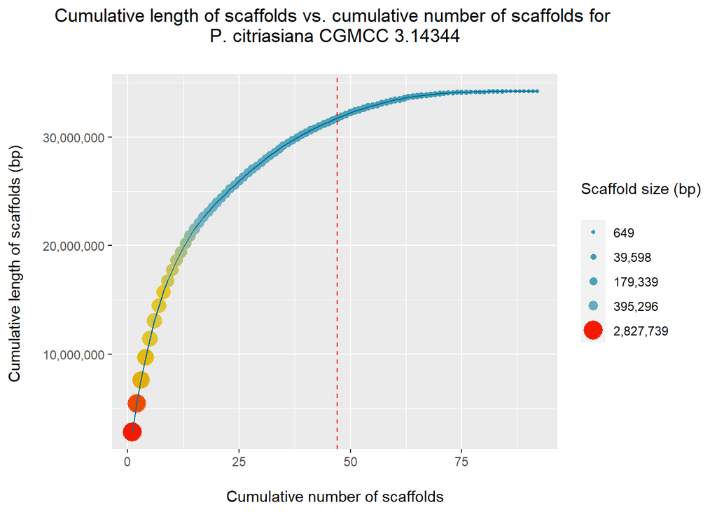

```r
PCitriasiana_CGMCC314344_final_plot
```

# *Phyllosticta citribraziliensis*

```r
dir.create("PCitribraziliensis")
```

## *Phyllosticta citribraziliensis* CBS 100098

Reading data

```r
# Read scaffold/contig lengths with read.fasta from seqinr
PCitribraziliensis_CBS100098_fasta <- read.fasta("PCitribraziliensis_CBS100098.fasta")
PCitribraziliensis_CBS100098_lengths <- getLength(PCitribraziliensis_CBS100098_fasta)

#Length sum, percentage of total length, cumulative sum
PCitribraziliensis_CBS100098_length_sum <- sum(PCitribraziliensis_CBS100098_lengths)
PCitribraziliensis_CBS100098_perc <- PCitribraziliensis_CBS100098_lengths/PCitribraziliensis_CBS100098_length_sum
PCitribraziliensis_CBS100098_length_cumsum <- cumsum(PCitribraziliensis_CBS100098_lengths)
PCitribraziliensis_CBS100098_perc_cumsum <- cumsum(PCitribraziliensis_CBS100098_perc)

#Creating a data frame for ggplot
PCitribraziliensis_CBS100098_df <- data.frame(PCitribraziliensis_CBS100098_lengths, PCitribraziliensis_CBS100098_perc)
```

Plotting cumulative sum of lengths and saving image

```r
# Adjusting colour palette according to number of contigs
PCitribraziliensis_CBS100098_colours <- c(wes_palette("Zissou1", length(PCitribraziliensis_CBS100098_lengths), type="continuous"))

PCitribraziliensis_CBS100098_length_title <- paste("Cumulative length of scaffolds vs. cumulative number of scaffolds for \n", "P. citribraziliensis CBS 100098 \n")

PCitribraziliensis_CBS100098_length_plot <-
  ggplot(PCitribraziliensis_CBS100098_df,
         aes(x=1:length(PCitribraziliensis_CBS100098_length_cumsum),
             y=PCitribraziliensis_CBS100098_length_cumsum)) +
  geom_point(aes(size=PCitribraziliensis_CBS100098_lengths, color = PCitribraziliensis_CBS100098_lengths)) +
  scale_size_continuous(name = "Scaffold size (bp)\n", breaks = fivenum(PCitribraziliensis_CBS100098_df$PCitribraziliensis_CBS100098_lengths), labels = comma(fivenum(PCitribraziliensis_CBS100098_df$PCitribraziliensis_CBS100098_lengths))) +
  geom_vline(xintercept=25, linetype="dashed", color = "red") +
  scale_color_continuous(low = head(PCitribraziliensis_CBS100098_colours), high = tail(PCitribraziliensis_CBS100098_colours), name = "Scaffold size (bp)\n", guide = "legend", breaks = fivenum(PCitribraziliensis_CBS100098_df$PCitribraziliensis_CBS100098_lengths), labels = comma(fivenum(PCitribraziliensis_CBS100098_df$PCitribraziliensis_CBS100098_lengths))) + geom_line(color="#046C9A")

## Final plot

PCitribraziliensis_CBS100098_final_plot <-
  PCitribraziliensis_CBS100098_length_plot +
  ggtitle(PCitribraziliensis_CBS100098_length_title) +
  xlab("\nCumulative number of scaffolds") +
  ylab("Cumulative length of scaffolds (bp) \n") +
  theme(plot.title = element_text(hjust = 0.5)) +
   scale_y_continuous(label=comma)

png("./PCitribraziliensis/PCitribraziliensis_CBS100098.png")
  PCitribraziliensis_CBS100098_final_plot
dev.off()
```

```r
pdf("./PCitribraziliensis/PCitribraziliensis_CBS100098.pdf")
  PCitribraziliensis_CBS100098_final_plot
dev.off()
```

```r
svg("./PCitribraziliensis/PCitribraziliensis_CBS100098.svg")
  PCitribraziliensis_CBS100098_final_plot
dev.off()
```

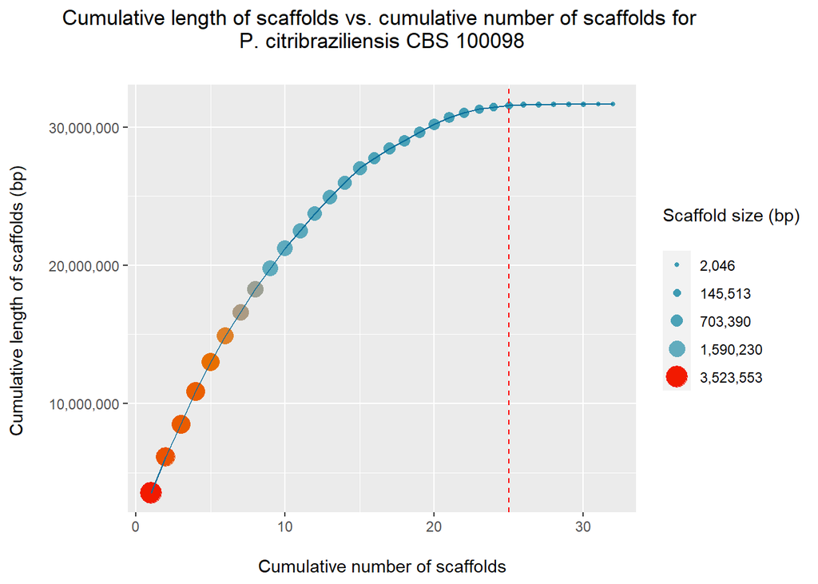

```r
PCitribraziliensis_CBS100098_final_plot
```

## *Phyllosticta citribraziliensis* LGMF 08

Reading data

```r
# Read scaffold/contig lengths with read.fasta from seqinr
PCitribraziliensis_LGMF08_fasta <- read.fasta("PCitribraziliensis_LGMF08.fasta")
PCitribraziliensis_LGMF08_lengths <- getLength(PCitribraziliensis_LGMF08_fasta)

#Length sum, percentage of total length, cumulative sum
PCitribraziliensis_LGMF08_length_sum <- sum(PCitribraziliensis_LGMF08_lengths)
PCitribraziliensis_LGMF08_perc <- PCitribraziliensis_LGMF08_lengths/PCitribraziliensis_LGMF08_length_sum
PCitribraziliensis_LGMF08_length_cumsum <- cumsum(PCitribraziliensis_LGMF08_lengths)
PCitribraziliensis_LGMF08_perc_cumsum <- cumsum(PCitribraziliensis_LGMF08_perc)

#Creating a data frame for ggplot
PCitribraziliensis_LGMF08_df <- data.frame(PCitribraziliensis_LGMF08_lengths, PCitribraziliensis_LGMF08_perc)
```

Plotting cumulative sum of lengths and saving image

```r
# Adjusting colour palette according to number of contigs
PCitribraziliensis_LGMF08_colours <- c(wes_palette("Zissou1", length(PCitribraziliensis_LGMF08_lengths), type="continuous"))

PCitribraziliensis_LGMF08_length_title <- paste("Cumulative length of scaffolds vs. cumulative number of scaffolds for \n", "P. citribraziliensis LGMF 08 \n")

PCitribraziliensis_LGMF08_length_plot <-
  ggplot(PCitribraziliensis_LGMF08_df,
         aes(x=1:length(PCitribraziliensis_LGMF08_length_cumsum),
             y=PCitribraziliensis_LGMF08_length_cumsum)) +
  geom_point(aes(size=PCitribraziliensis_LGMF08_lengths, color = PCitribraziliensis_LGMF08_lengths)) +
  scale_size_continuous(name = "Scaffold size (bp)\n", breaks = fivenum(PCitribraziliensis_LGMF08_df$PCitribraziliensis_LGMF08_lengths), labels = comma(fivenum(PCitribraziliensis_LGMF08_df$PCitribraziliensis_LGMF08_lengths))) +
  geom_vline(xintercept=75, linetype="dashed", color = "red") +
  scale_color_continuous(low = head(PCitribraziliensis_LGMF08_colours), high = tail(PCitribraziliensis_LGMF08_colours), name = "Scaffold size (bp)\n", guide = "legend", breaks = fivenum(PCitribraziliensis_LGMF08_df$PCitribraziliensis_LGMF08_lengths), labels = comma(fivenum(PCitribraziliensis_LGMF08_df$PCitribraziliensis_LGMF08_lengths))) + geom_line(color="#046C9A")

## Final plot

PCitribraziliensis_LGMF08_final_plot <-
  PCitribraziliensis_LGMF08_length_plot +
  ggtitle(PCitribraziliensis_LGMF08_length_title) +
  xlab("\nCumulative number of scaffolds") +
  ylab("Cumulative length of scaffolds (bp) \n") +
  theme(plot.title = element_text(hjust = 0.5)) +
   scale_y_continuous(label=comma)

png("./PCitribraziliensis/PCitribraziliensis_LGMF08.png")
  PCitribraziliensis_LGMF08_final_plot
dev.off()
```

```r
pdf("./PCitribraziliensis/PCitribraziliensis_LGMF08.pdf")
  PCitribraziliensis_LGMF08_final_plot
dev.off()
```

```r
svg("./PCitribraziliensis/PCitribraziliensis_LGMF08.svg")
  PCitribraziliensis_LGMF08_final_plot
dev.off()
```

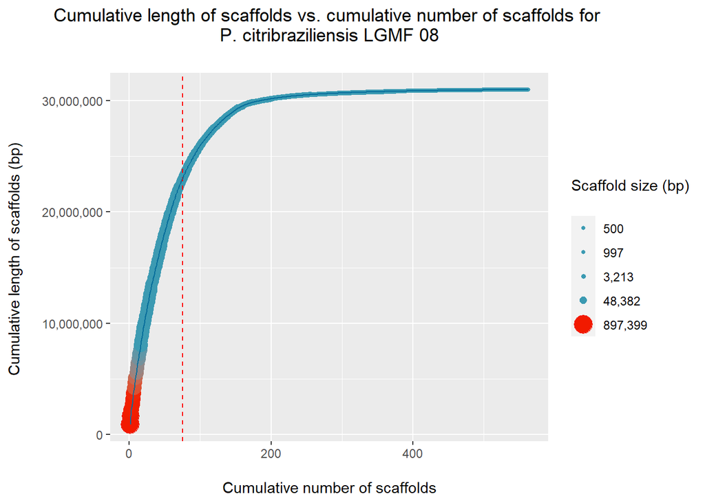

```r
PCitribraziliensis_LGMF08_final_plot
```

## *Phyllosticta citribraziliensis* CPC 17464

Reading data

```r
# Read scaffold/contig lengths with read.fasta from seqinr
PCitribraziliensis_CPC17464_fasta <- read.fasta("PCitribraziliensis_CPC17464.fasta")
PCitribraziliensis_CPC17464_lengths <- getLength(PCitribraziliensis_CPC17464_fasta)

#Length sum, percentage of total length, cumulative sum
PCitribraziliensis_CPC17464_length_sum <- sum(PCitribraziliensis_CPC17464_lengths)
PCitribraziliensis_CPC17464_perc <- PCitribraziliensis_CPC17464_lengths/PCitribraziliensis_CPC17464_length_sum
PCitribraziliensis_CPC17464_length_cumsum <- cumsum(PCitribraziliensis_CPC17464_lengths)
PCitribraziliensis_CPC17464_perc_cumsum <- cumsum(PCitribraziliensis_CPC17464_perc)

#Creating a data frame for ggplot
PCitribraziliensis_CPC17464_df <- data.frame(PCitribraziliensis_CPC17464_lengths, PCitribraziliensis_CPC17464_perc)
```

Plotting cumulative sum of lengths and saving image

```r
# Adjusting colour palette according to number of contigs
PCitribraziliensis_CPC17464_colours <- c(wes_palette("Zissou1", length(PCitribraziliensis_CPC17464_lengths), type="continuous"))

PCitribraziliensis_CPC17464_length_title <- paste("Cumulative length of scaffolds vs. cumulative number of scaffolds for \n", "P. citribraziliensis CPC 17464 \n")

PCitribraziliensis_CPC17464_length_plot <-
  ggplot(PCitribraziliensis_CPC17464_df,
         aes(x=1:length(PCitribraziliensis_CPC17464_length_cumsum),
             y=PCitribraziliensis_CPC17464_length_cumsum)) +
  geom_point(aes(size=PCitribraziliensis_CPC17464_lengths, color = PCitribraziliensis_CPC17464_lengths)) +
  scale_size_continuous(name = "Scaffold size (bp)\n", breaks = fivenum(PCitribraziliensis_CPC17464_df$PCitribraziliensis_CPC17464_lengths), labels = comma(fivenum(PCitribraziliensis_CPC17464_df$PCitribraziliensis_CPC17464_lengths))) +
  geom_vline(xintercept=18, linetype="dashed", color = "red") +
  scale_color_continuous(low = head(PCitribraziliensis_CPC17464_colours), high = tail(PCitribraziliensis_CPC17464_colours), name = "Scaffold size (bp)\n", guide = "legend", breaks = fivenum(PCitribraziliensis_CPC17464_df$PCitribraziliensis_CPC17464_lengths), labels = comma(fivenum(PCitribraziliensis_CPC17464_df$PCitribraziliensis_CPC17464_lengths))) + geom_line(color="#046C9A")

## Final plot

PCitribraziliensis_CPC17464_final_plot <-
  PCitribraziliensis_CPC17464_length_plot +
  ggtitle(PCitribraziliensis_CPC17464_length_title) +
  xlab("\nCumulative number of scaffolds") +
  ylab("Cumulative length of scaffolds (bp) \n") +
  theme(plot.title = element_text(hjust = 0.5)) +
   scale_y_continuous(label=comma)

png("./PCitribraziliensis/PCitribraziliensis_CPC17464.png")
  PCitribraziliensis_CPC17464_final_plot
dev.off()
```

```r
pdf("./PCitribraziliensis/PCitribraziliensis_CPC17464.pdf")
  PCitribraziliensis_CPC17464_final_plot
dev.off()
```

```r
svg("./PCitribraziliensis/PCitribraziliensis_CPC17464.svg")
  PCitribraziliensis_CPC17464_final_plot
dev.off()
```

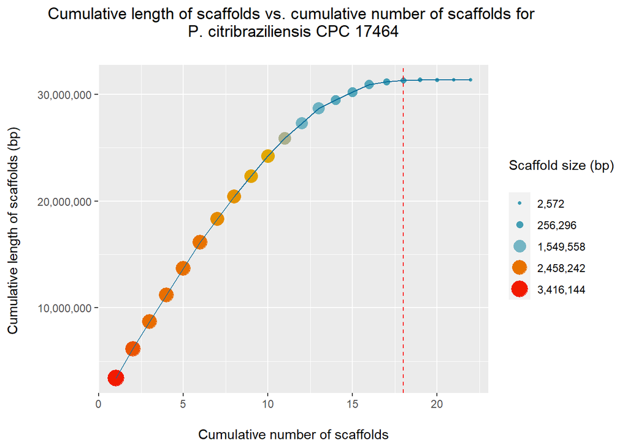

```r
PCitribraziliensis_CPC17464_final_plot
```

# *Phyllosticta citricarpa*

```r
dir.create("PCitricarpa")
```

## *Phyllosticta citricarpa* CBS 111.20

Reading data

```r
# Read scaffold/contig lengths with read.fasta from seqinr
PCitricarpa_CBS111_20_fasta <- read.fasta("PCitricarpa_CBS111_20.fasta")
PCitricarpa_CBS111_20_lengths <- getLength(PCitricarpa_CBS111_20_fasta)

#Length sum, percentage of total length, cumulative sum
PCitricarpa_CBS111_20_length_sum <- sum(PCitricarpa_CBS111_20_lengths)
PCitricarpa_CBS111_20_perc <- PCitricarpa_CBS111_20_lengths/PCitricarpa_CBS111_20_length_sum
PCitricarpa_CBS111_20_length_cumsum <- cumsum(PCitricarpa_CBS111_20_lengths)
PCitricarpa_CBS111_20_perc_cumsum <- cumsum(PCitricarpa_CBS111_20_perc)

#Creating a data frame for ggplot
PCitricarpa_CBS111_20_df <- data.frame(PCitricarpa_CBS111_20_lengths, PCitricarpa_CBS111_20_perc)
```

Plotting cumulative sum of lengths and saving image

```r
# Adjusting colour palette according to number of contigs
PCitricarpa_CBS111_20_colours <- c(wes_palette("Zissou1", length(PCitricarpa_CBS111_20_lengths), type="continuous"))

PCitricarpa_CBS111_20_length_title <- paste("Cumulative length of scaffolds vs. cumulative number of scaffolds for \n", "P. citricarpa CBS 111.20 \n")

PCitricarpa_CBS111_20_length_plot <-
  ggplot(PCitricarpa_CBS111_20_df,
         aes(x=1:length(PCitricarpa_CBS111_20_length_cumsum),
             y=PCitricarpa_CBS111_20_length_cumsum)) +
  geom_point(aes(size=PCitricarpa_CBS111_20_lengths, color = PCitricarpa_CBS111_20_lengths)) +
  scale_size_continuous(name = "Scaffold size (bp)\n", breaks = fivenum(PCitricarpa_CBS111_20_df$PCitricarpa_CBS111_20_lengths), labels = comma(fivenum(PCitricarpa_CBS111_20_df$PCitricarpa_CBS111_20_lengths))) +
  geom_vline(xintercept=71, linetype="dashed", color = "red") +
  scale_color_continuous(low = head(PCitricarpa_CBS111_20_colours), high = tail(PCitricarpa_CBS111_20_colours), name = "Scaffold size (bp)\n", guide = "legend", breaks = fivenum(PCitricarpa_CBS111_20_df$PCitricarpa_CBS111_20_lengths), labels = comma(fivenum(PCitricarpa_CBS111_20_df$PCitricarpa_CBS111_20_lengths))) + geom_line(color="#046C9A")

## Final plot

PCitricarpa_CBS111_20_final_plot <-
  PCitricarpa_CBS111_20_length_plot +
  ggtitle(PCitricarpa_CBS111_20_length_title) +
  xlab("\nCumulative number of scaffolds") +
  ylab("Cumulative length of scaffolds (bp) \n") +
  theme(plot.title = element_text(hjust = 0.5)) +
   scale_y_continuous(label=comma)

png("./PCitricarpa/PCitricarpa_CBS111_20.png")
  PCitricarpa_CBS111_20_final_plot
dev.off()
```

```r
pdf("./PCitricarpa/PCitricarpa_CBS111_20.pdf")
  PCitricarpa_CBS111_20_final_plot
dev.off()
```

```r
svg("./PCitricarpa/PCitricarpa_CBS111_20.svg")
  PCitricarpa_CBS111_20_final_plot
dev.off()
```

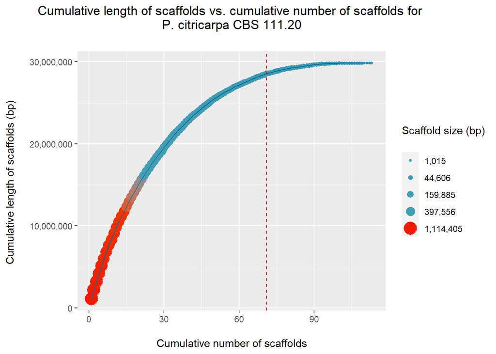

```r
PCitricarpa_CBS111_20_final_plot
```

## *Phyllosticta citricarpa* CBS 102373

Reading data

```r
# Read scaffold/contig lengths with read.fasta from seqinr
PCitricarpa_CBS102373_fasta <- read.fasta("PCitricarpa_CBS102373.fasta")
PCitricarpa_CBS102373_lengths <- getLength(PCitricarpa_CBS102373_fasta)

#Length sum, percentage of total length, cumulative sum
PCitricarpa_CBS102373_length_sum <- sum(PCitricarpa_CBS102373_lengths)
PCitricarpa_CBS102373_perc <- PCitricarpa_CBS102373_lengths/PCitricarpa_CBS102373_length_sum
PCitricarpa_CBS102373_length_cumsum <- cumsum(PCitricarpa_CBS102373_lengths)
PCitricarpa_CBS102373_perc_cumsum <- cumsum(PCitricarpa_CBS102373_perc)

#Creating a data frame for ggplot
PCitricarpa_CBS102373_df <- data.frame(PCitricarpa_CBS102373_lengths, PCitricarpa_CBS102373_perc)
```

Plotting cumulative sum of lengths and saving image

```r
# Adjusting colour palette according to number of contigs
PCitricarpa_CBS102373_colours <- c(wes_palette("Zissou1", length(PCitricarpa_CBS102373_lengths), type="continuous"))

PCitricarpa_CBS102373_length_title <- paste("Cumulative length of scaffolds vs. cumulative number of scaffolds for \n", "P. citricarpa CBS 102373 \n")

PCitricarpa_CBS102373_length_plot <-
  ggplot(PCitricarpa_CBS102373_df,
         aes(x=1:length(PCitricarpa_CBS102373_length_cumsum),
             y=PCitricarpa_CBS102373_length_cumsum)) +
  geom_point(aes(size=PCitricarpa_CBS102373_lengths, color = PCitricarpa_CBS102373_lengths)) +
  scale_size_continuous(name = "Scaffold size (bp)\n", breaks = fivenum(PCitricarpa_CBS102373_df$PCitricarpa_CBS102373_lengths), labels = comma(fivenum(PCitricarpa_CBS102373_df$PCitricarpa_CBS102373_lengths))) +
  geom_vline(xintercept=65, linetype="dashed", color = "red") +
  scale_color_continuous(low = head(PCitricarpa_CBS102373_colours), high = tail(PCitricarpa_CBS102373_colours), name = "Scaffold size (bp)\n", guide = "legend", breaks = fivenum(PCitricarpa_CBS102373_df$PCitricarpa_CBS102373_lengths), labels = comma(fivenum(PCitricarpa_CBS102373_df$PCitricarpa_CBS102373_lengths))) + geom_line(color="#046C9A")

## Final plot

PCitricarpa_CBS102373_final_plot <-
  PCitricarpa_CBS102373_length_plot +
  ggtitle(PCitricarpa_CBS102373_length_title) +
  xlab("\nCumulative number of scaffolds") +
  ylab("Cumulative length of scaffolds (bp) \n") +
  theme(plot.title = element_text(hjust = 0.5)) +
   scale_y_continuous(label=comma)

png("./PCitricarpa/PCitricarpa_CBS102373.png")
  PCitricarpa_CBS102373_final_plot
dev.off()
```

```r
pdf("./PCitricarpa/PCitricarpa_CBS102373.pdf")
  PCitricarpa_CBS102373_final_plot
dev.off()
```

```r
svg("./PCitricarpa/PCitricarpa_CBS102373.svg")
  PCitricarpa_CBS102373_final_plot
dev.off()
```

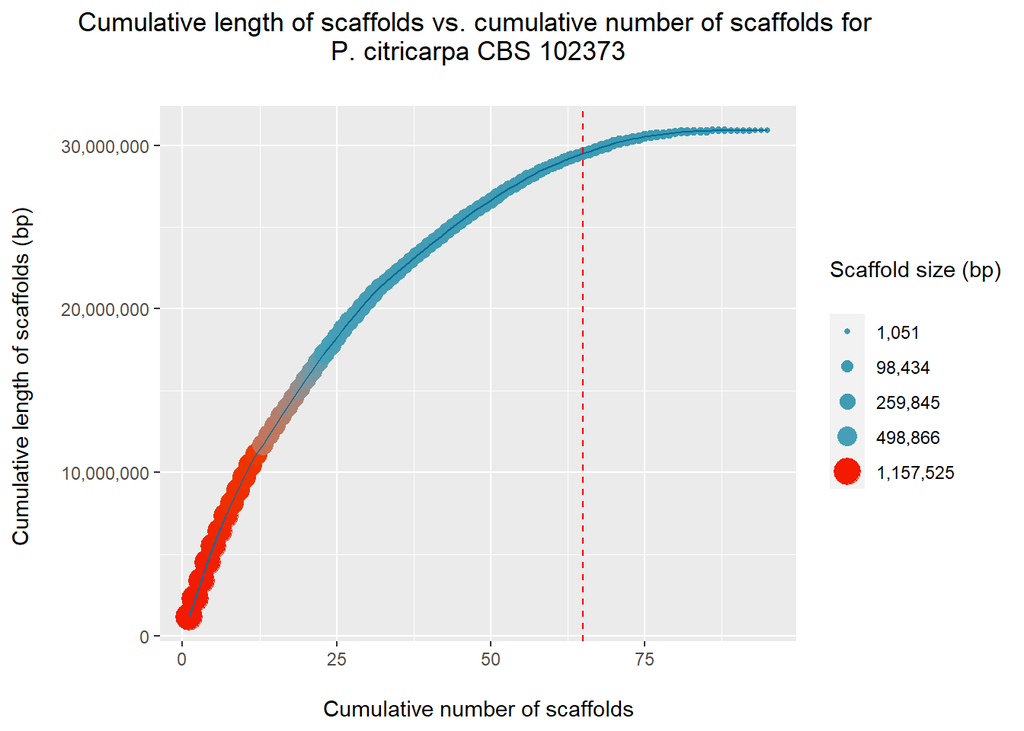

```r
PCitricarpa_CBS102373_final_plot
```

## *Phyllosticta citricarpa* CBS 122482

Reading data

```r
# Read scaffold/contig lengths with read.fasta from seqinr
PCitricarpa_CBS122482_fasta <- read.fasta("PCitricarpa_CBS122482.fasta")
PCitricarpa_CBS122482_lengths <- getLength(PCitricarpa_CBS122482_fasta)

#Length sum, percentage of total length, cumulative sum
PCitricarpa_CBS122482_length_sum <- sum(PCitricarpa_CBS122482_lengths)
PCitricarpa_CBS122482_perc <- PCitricarpa_CBS122482_lengths/PCitricarpa_CBS122482_length_sum
PCitricarpa_CBS122482_length_cumsum <- cumsum(PCitricarpa_CBS122482_lengths)
PCitricarpa_CBS122482_perc_cumsum <- cumsum(PCitricarpa_CBS122482_perc)

#Creating a data frame for ggplot
PCitricarpa_CBS122482_df <- data.frame(PCitricarpa_CBS122482_lengths, PCitricarpa_CBS122482_perc)
```

Plotting cumulative sum of lengths and saving image

```r
# Adjusting colour palette according to number of contigs
PCitricarpa_CBS122482_colours <- c(wes_palette("Zissou1", length(PCitricarpa_CBS122482_lengths), type="continuous"))

PCitricarpa_CBS122482_length_title <- paste("Cumulative length of scaffolds vs. cumulative number of scaffolds for \n", "P. citricarpa CBS 122482 \n")

PCitricarpa_CBS122482_length_plot <-
  ggplot(PCitricarpa_CBS122482_df,
         aes(x=1:length(PCitricarpa_CBS122482_length_cumsum),
             y=PCitricarpa_CBS122482_length_cumsum)) +
  geom_point(aes(size=PCitricarpa_CBS122482_lengths, color = PCitricarpa_CBS122482_lengths)) +
  scale_size_continuous(name = "Scaffold size (bp)\n", breaks = fivenum(PCitricarpa_CBS122482_df$PCitricarpa_CBS122482_lengths), labels = comma(fivenum(PCitricarpa_CBS122482_df$PCitricarpa_CBS122482_lengths))) +
  geom_vline(xintercept=60, linetype="dashed", color = "red") +
  scale_color_continuous(low = head(PCitricarpa_CBS122482_colours), high = tail(PCitricarpa_CBS122482_colours), name = "Scaffold size (bp)\n", guide = "legend", breaks = fivenum(PCitricarpa_CBS122482_df$PCitricarpa_CBS122482_lengths), labels = comma(fivenum(PCitricarpa_CBS122482_df$PCitricarpa_CBS122482_lengths))) + geom_line(color="#046C9A")

## Final plot

PCitricarpa_CBS122482_final_plot <-
  PCitricarpa_CBS122482_length_plot +
  ggtitle(PCitricarpa_CBS122482_length_title) +
  xlab("\nCumulative number of scaffolds") +
  ylab("Cumulative length of scaffolds (bp) \n") +
  theme(plot.title = element_text(hjust = 0.5)) +
   scale_y_continuous(label=comma)

png("./PCitricarpa/PCitricarpa_CBS122482.png")
  PCitricarpa_CBS122482_final_plot
dev.off()
```

```r
pdf("./PCitricarpa/PCitricarpa_CBS122482.pdf")
  PCitricarpa_CBS122482_final_plot
dev.off()
```

```r
svg("./PCitricarpa/PCitricarpa_CBS122482.svg")
  PCitricarpa_CBS122482_final_plot
dev.off()
```

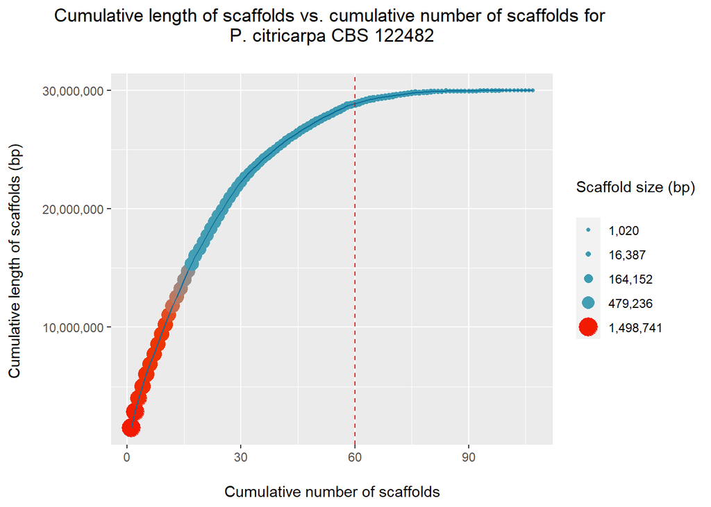

```r
PCitricarpa_CBS122482_final_plot
```

## *Phyllosticta citricarpa* CBS 122670

Reading data

```r
# Read scaffold/contig lengths with read.fasta from seqinr
PCitricarpa_CBS122670_fasta <- read.fasta("PCitricarpa_CBS122670.fasta")
PCitricarpa_CBS122670_lengths <- getLength(PCitricarpa_CBS122670_fasta)

#Length sum, percentage of total length, cumulative sum
PCitricarpa_CBS122670_length_sum <- sum(PCitricarpa_CBS122670_lengths)
PCitricarpa_CBS122670_perc <- PCitricarpa_CBS122670_lengths/PCitricarpa_CBS122670_length_sum
PCitricarpa_CBS122670_length_cumsum <- cumsum(PCitricarpa_CBS122670_lengths)
PCitricarpa_CBS122670_perc_cumsum <- cumsum(PCitricarpa_CBS122670_perc)

#Creating a data frame for ggplot
PCitricarpa_CBS122670_df <- data.frame(PCitricarpa_CBS122670_lengths, PCitricarpa_CBS122670_perc)
```

Plotting cumulative sum of lengths and saving image

```r
# Adjusting colour palette according to number of contigs
PCitricarpa_CBS122670_colours <- c(wes_palette("Zissou1", length(PCitricarpa_CBS122670_lengths), type="continuous"))

PCitricarpa_CBS122670_length_title <- paste("Cumulative length of scaffolds vs. cumulative number of scaffolds for \n", "P. citricarpa CBS 122670 \n")

PCitricarpa_CBS122670_length_plot <-
  ggplot(PCitricarpa_CBS122670_df,
         aes(x=1:length(PCitricarpa_CBS122670_length_cumsum),
             y=PCitricarpa_CBS122670_length_cumsum)) +
  geom_point(aes(size=PCitricarpa_CBS122670_lengths, color = PCitricarpa_CBS122670_lengths)) +
  scale_size_continuous(name = "Scaffold size (bp)\n", breaks = fivenum(PCitricarpa_CBS122670_df$PCitricarpa_CBS122670_lengths), labels = comma(fivenum(PCitricarpa_CBS122670_df$PCitricarpa_CBS122670_lengths))) +
  geom_vline(xintercept=67, linetype="dashed", color = "red") +
  scale_color_continuous(low = head(PCitricarpa_CBS122670_colours), high = tail(PCitricarpa_CBS122670_colours), name = "Scaffold size (bp)\n", guide = "legend", breaks = fivenum(PCitricarpa_CBS122670_df$PCitricarpa_CBS122670_lengths), labels = comma(fivenum(PCitricarpa_CBS122670_df$PCitricarpa_CBS122670_lengths))) + geom_line(color="#046C9A")

## Final plot

PCitricarpa_CBS122670_final_plot <-
  PCitricarpa_CBS122670_length_plot +
  ggtitle(PCitricarpa_CBS122670_length_title) +
  xlab("\nCumulative number of scaffolds") +
  ylab("Cumulative length of scaffolds (bp) \n") +
  theme(plot.title = element_text(hjust = 0.5)) +
   scale_y_continuous(label=comma)

png("./PCitricarpa/PCitricarpa_CBS122670.png")
  PCitricarpa_CBS122670_final_plot
dev.off()
```

```r
pdf("./PCitricarpa/PCitricarpa_CBS122670.pdf")
  PCitricarpa_CBS122670_final_plot
dev.off()
```

```r
svg("./PCitricarpa/PCitricarpa_CBS122670.svg")
  PCitricarpa_CBS122670_final_plot
dev.off()
```

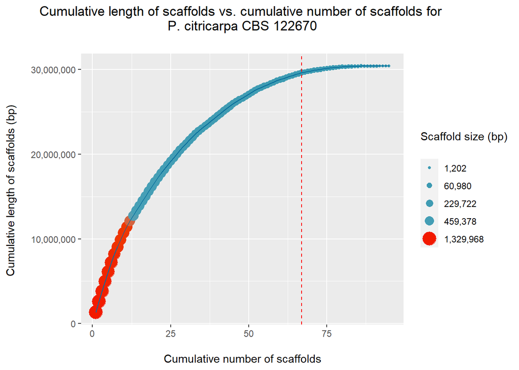

```r
PCitricarpa_CBS122670_final_plot
```

### *Phyllosticta citricarpa* CBS 127454

Reading data

```r
# Read scaffold/contig lengths with read.fasta from seqinr
PCitricarpa_CBS127454_fasta <- read.fasta("PCitricarpa_CBS127454.fasta")
PCitricarpa_CBS127454_lengths <- getLength(PCitricarpa_CBS127454_fasta)

#Length sum, percentage of total length, cumulative sum
PCitricarpa_CBS127454_length_sum <- sum(PCitricarpa_CBS127454_lengths)
PCitricarpa_CBS127454_perc <- PCitricarpa_CBS127454_lengths/PCitricarpa_CBS127454_length_sum
PCitricarpa_CBS127454_length_cumsum <- cumsum(PCitricarpa_CBS127454_lengths)
PCitricarpa_CBS127454_perc_cumsum <- cumsum(PCitricarpa_CBS127454_perc)

#Creating a data frame for ggplot
PCitricarpa_CBS127454_df <- data.frame(PCitricarpa_CBS127454_lengths, PCitricarpa_CBS127454_perc)
```

Plotting cumulative sum of lengths and saving image

```r
# Adjusting colour palette according to number of contigs
PCitricarpa_CBS127454_colours <- c(wes_palette("Zissou1", length(PCitricarpa_CBS127454_lengths), type="continuous"))

PCitricarpa_CBS127454_length_title <- paste("Cumulative length of scaffolds vs. cumulative number of scaffolds for \n", "P. citricarpa CBS 127454 \n")

PCitricarpa_CBS127454_length_plot <-
  ggplot(PCitricarpa_CBS127454_df,
         aes(x=1:length(PCitricarpa_CBS127454_length_cumsum),
             y=PCitricarpa_CBS127454_length_cumsum)) +
  geom_point(aes(size=PCitricarpa_CBS127454_lengths, color = PCitricarpa_CBS127454_lengths)) +
  scale_size_continuous(name = "Scaffold size (bp)\n", breaks = fivenum(PCitricarpa_CBS127454_df$PCitricarpa_CBS127454_lengths), labels = comma(fivenum(PCitricarpa_CBS127454_df$PCitricarpa_CBS127454_lengths))) +
  geom_vline(xintercept=79, linetype="dashed", color = "red") +
  scale_color_continuous(low = head(PCitricarpa_CBS127454_colours), high = tail(PCitricarpa_CBS127454_colours), name = "Scaffold size (bp)\n", guide = "legend", breaks = fivenum(PCitricarpa_CBS127454_df$PCitricarpa_CBS127454_lengths), labels = comma(fivenum(PCitricarpa_CBS127454_df$PCitricarpa_CBS127454_lengths))) + geom_line(color="#046C9A")

## Final plot

PCitricarpa_CBS127454_final_plot <-
  PCitricarpa_CBS127454_length_plot +
  ggtitle(PCitricarpa_CBS127454_length_title) +
  xlab("\nCumulative number of scaffolds") +
  ylab("Cumulative length of scaffolds (bp) \n") +
  theme(plot.title = element_text(hjust = 0.5)) +
   scale_y_continuous(label=comma)

png("./PCitricarpa/PCitricarpa_CBS127454.png")
  PCitricarpa_CBS127454_final_plot
dev.off()
```

```r
pdf("./PCitricarpa/PCitricarpa_CBS127454.pdf")
  PCitricarpa_CBS127454_final_plot
dev.off()
```

```r
svg("./PCitricarpa/PCitricarpa_CBS127454.svg")
  PCitricarpa_CBS127454_final_plot
dev.off()
```

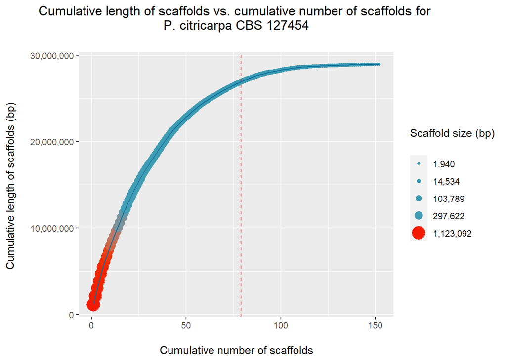

```r
PCitricarpa_CBS127454_final_plot
```

## *Phyllosticta citricarpa* CBS 131864

Reading data

```r
# Read scaffold/contig lengths with read.fasta from seqinr
PCitricarpa_CBS131864_fasta <- read.fasta("PCitricarpa_CBS131864.fasta")
PCitricarpa_CBS131864_lengths <- getLength(PCitricarpa_CBS131864_fasta)

#Length sum, percentage of total length, cumulative sum
PCitricarpa_CBS131864_length_sum <- sum(PCitricarpa_CBS131864_lengths)
PCitricarpa_CBS131864_perc <- PCitricarpa_CBS131864_lengths/PCitricarpa_CBS131864_length_sum
PCitricarpa_CBS131864_length_cumsum <- cumsum(PCitricarpa_CBS131864_lengths)
PCitricarpa_CBS131864_perc_cumsum <- cumsum(PCitricarpa_CBS131864_perc)

#Creating a data frame for ggplot
PCitricarpa_CBS131864_df <- data.frame(PCitricarpa_CBS131864_lengths, PCitricarpa_CBS131864_perc)
```

Plotting cumulative sum of lengths and saving image

```r
# Adjusting colour palette according to number of contigs
PCitricarpa_CBS131864_colours <- c(wes_palette("Zissou1", length(PCitricarpa_CBS131864_lengths), type="continuous"))

PCitricarpa_CBS131864_length_title <- paste("Cumulative length of scaffolds vs. cumulative number of scaffolds for \n", "P. citricarpa CBS 131864 \n")

PCitricarpa_CBS131864_length_plot <-
  ggplot(PCitricarpa_CBS131864_df,
         aes(x=1:length(PCitricarpa_CBS131864_length_cumsum),
             y=PCitricarpa_CBS131864_length_cumsum)) +
  geom_point(aes(size=PCitricarpa_CBS131864_lengths, color = PCitricarpa_CBS131864_lengths)) +
  scale_size_continuous(name = "Scaffold size (bp)\n", breaks = fivenum(PCitricarpa_CBS131864_df$PCitricarpa_CBS131864_lengths), labels = comma(fivenum(PCitricarpa_CBS131864_df$PCitricarpa_CBS131864_lengths))) +
  geom_vline(xintercept=69, linetype="dashed", color = "red") +
  scale_color_continuous(low = head(PCitricarpa_CBS131864_colours), high = tail(PCitricarpa_CBS131864_colours), name = "Scaffold size (bp)\n", guide = "legend", breaks = fivenum(PCitricarpa_CBS131864_df$PCitricarpa_CBS131864_lengths), labels = comma(fivenum(PCitricarpa_CBS131864_df$PCitricarpa_CBS131864_lengths))) + geom_line(color="#046C9A")

## Final plot

PCitricarpa_CBS131864_final_plot <-
  PCitricarpa_CBS131864_length_plot +
  ggtitle(PCitricarpa_CBS131864_length_title) +
  xlab("\nCumulative number of scaffolds") +
  ylab("Cumulative length of scaffolds (bp) \n") +
  theme(plot.title = element_text(hjust = 0.5)) +
   scale_y_continuous(label=comma)

png("./PCitricarpa/PCitricarpa_CBS131864.png")
  PCitricarpa_CBS131864_final_plot
dev.off()
```

```r
pdf("./PCitricarpa/PCitricarpa_CBS131864.pdf")
  PCitricarpa_CBS131864_final_plot
dev.off()
```

```r
svg("./PCitricarpa/PCitricarpa_CBS131864.svg")
  PCitricarpa_CBS131864_final_plot
dev.off()
```

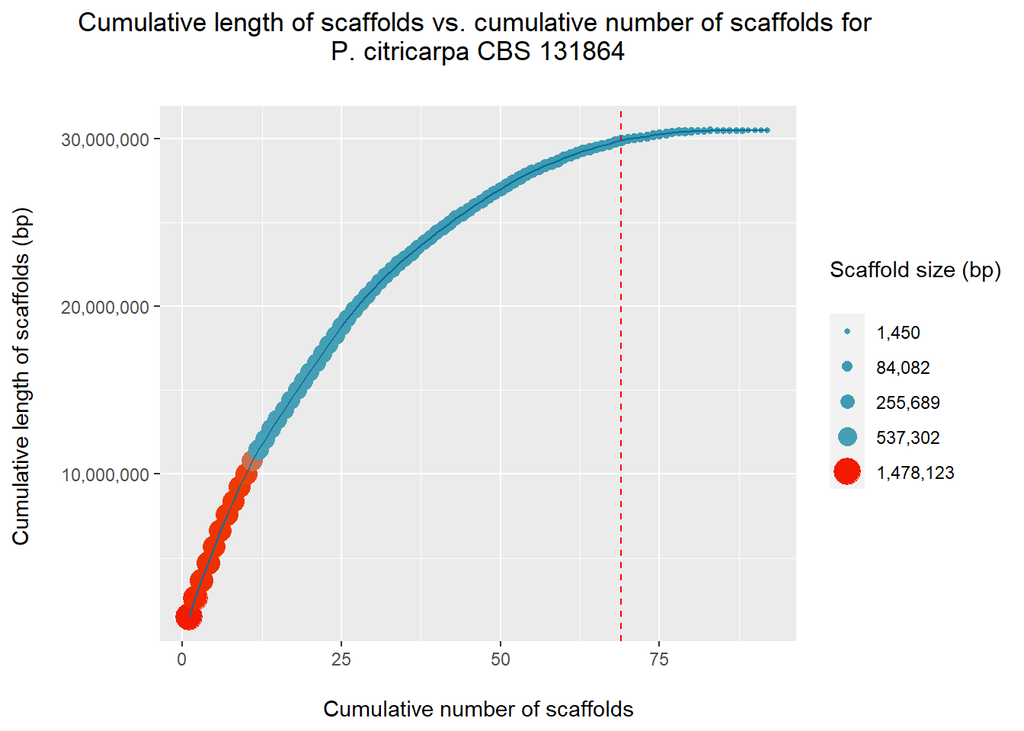

```r
PCitricarpa_CBS131864_final_plot
```

## *Phyllosticta citricarpa* CBS 141352

Reading data

```r
# Read scaffold/contig lengths with read.fasta from seqinr
PCitricarpa_CBS141352_fasta <- read.fasta("PCitricarpa_CBS141352.fasta")
PCitricarpa_CBS141352_lengths <- getLength(PCitricarpa_CBS141352_fasta)

#Length sum, percentage of total length, cumulative sum
PCitricarpa_CBS141352_length_sum <- sum(PCitricarpa_CBS141352_lengths)
PCitricarpa_CBS141352_perc <- PCitricarpa_CBS141352_lengths/PCitricarpa_CBS141352_length_sum
PCitricarpa_CBS141352_length_cumsum <- cumsum(PCitricarpa_CBS141352_lengths)
PCitricarpa_CBS141352_perc_cumsum <- cumsum(PCitricarpa_CBS141352_perc)

#Creating a data frame for ggplot
PCitricarpa_CBS141352_df <- data.frame(PCitricarpa_CBS141352_lengths, PCitricarpa_CBS141352_perc)
```

Plotting cumulative sum of lengths and saving image

```r
# Adjusting colour palette according to number of contigs
PCitricarpa_CBS141352_colours <- c(wes_palette("Zissou1", length(PCitricarpa_CBS141352_lengths), type="continuous"))

PCitricarpa_CBS141352_length_title <- paste("Cumulative length of scaffolds vs. cumulative number of scaffolds for \n", "P. citricarpa CBS 141352 \n")

PCitricarpa_CBS141352_length_plot <-
  ggplot(PCitricarpa_CBS141352_df,
         aes(x=1:length(PCitricarpa_CBS141352_length_cumsum),
             y=PCitricarpa_CBS141352_length_cumsum)) +
  geom_point(aes(size=PCitricarpa_CBS141352_lengths, color = PCitricarpa_CBS141352_lengths)) +
  scale_size_continuous(name = "Scaffold size (bp)\n", breaks = fivenum(PCitricarpa_CBS141352_df$PCitricarpa_CBS141352_lengths), labels = comma(fivenum(PCitricarpa_CBS141352_df$PCitricarpa_CBS141352_lengths))) +
  geom_vline(xintercept=70, linetype="dashed", color = "red") +
  scale_color_continuous(low = head(PCitricarpa_CBS141352_colours), high = tail(PCitricarpa_CBS141352_colours), name = "Scaffold size (bp)\n", guide = "legend", breaks = fivenum(PCitricarpa_CBS141352_df$PCitricarpa_CBS141352_lengths), labels = comma(fivenum(PCitricarpa_CBS141352_df$PCitricarpa_CBS141352_lengths))) + geom_line(color="#046C9A")

## Final plot

PCitricarpa_CBS141352_final_plot <-
  PCitricarpa_CBS141352_length_plot +
  ggtitle(PCitricarpa_CBS141352_length_title) +
  xlab("\nCumulative number of scaffolds") +
  ylab("Cumulative length of scaffolds (bp) \n") +
  theme(plot.title = element_text(hjust = 0.5)) +
   scale_y_continuous(label=comma)

png("./PCitricarpa/PCitricarpa_CBS141352.png")
  PCitricarpa_CBS141352_final_plot
dev.off()
```

```r
pdf("./PCitricarpa/PCitricarpa_CBS141352.pdf")
  PCitricarpa_CBS141352_final_plot
dev.off()
```

```r
svg("./PCitricarpa/PCitricarpa_CBS141352.svg")
  PCitricarpa_CBS141352_final_plot
dev.off()
```

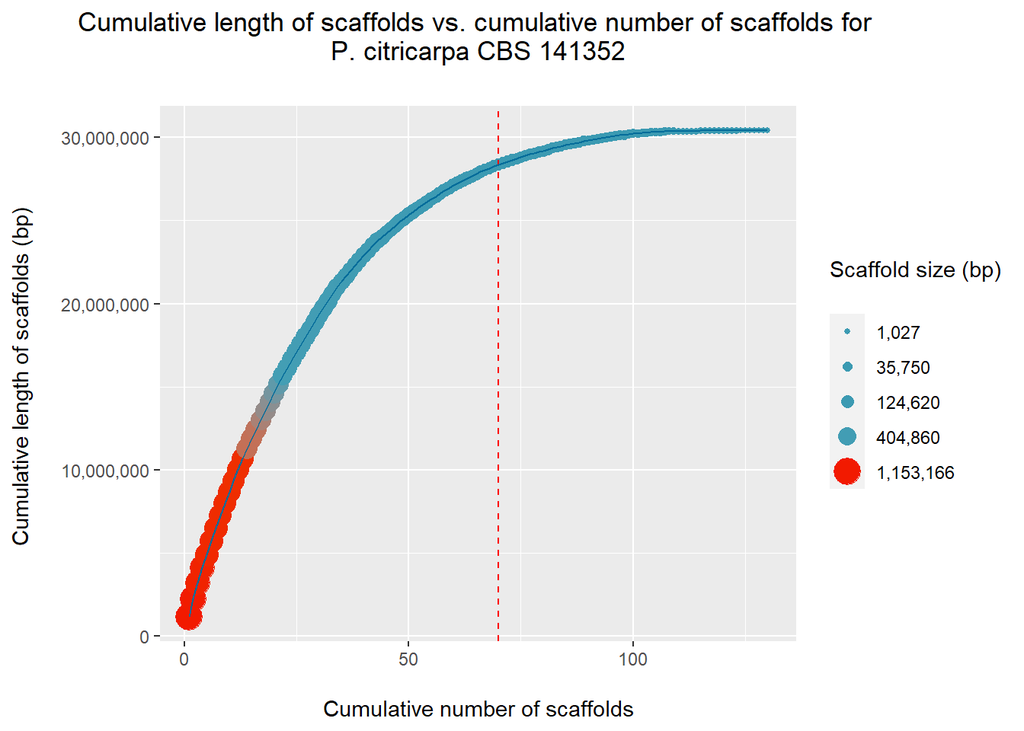

```r
PCitricarpa_CBS141352_final_plot
```

## *Phyllosticta citricarpa* CPC 16586

Reading data

```r
# Read scaffold/contig lengths with read.fasta from seqinr
PCitricarpa_CPC16586_fasta <- read.fasta("PCitricarpa_CPC16586.fasta")
PCitricarpa_CPC16586_lengths <- getLength(PCitricarpa_CPC16586_fasta)

#Length sum, percentage of total length, cumulative sum
PCitricarpa_CPC16586_length_sum <- sum(PCitricarpa_CPC16586_lengths)
PCitricarpa_CPC16586_perc <- PCitricarpa_CPC16586_lengths/PCitricarpa_CPC16586_length_sum
PCitricarpa_CPC16586_length_cumsum <- cumsum(PCitricarpa_CPC16586_lengths)
PCitricarpa_CPC16586_perc_cumsum <- cumsum(PCitricarpa_CPC16586_perc)

#Creating a data frame for ggplot
PCitricarpa_CPC16586_df <- data.frame(PCitricarpa_CPC16586_lengths, PCitricarpa_CPC16586_perc)
```

Plotting cumulative sum of lengths and saving image

```r
# Adjusting colour palette according to number of contigs
PCitricarpa_CPC16586_colours <- c(wes_palette("Zissou1", length(PCitricarpa_CPC16586_lengths), type="continuous"))

PCitricarpa_CPC16586_length_title <- paste("Cumulative length of scaffolds vs. cumulative number of scaffolds for \n", "P. citricarpa CPC 16586 \n")

PCitricarpa_CPC16586_length_plot <-
  ggplot(PCitricarpa_CPC16586_df,
         aes(x=1:length(PCitricarpa_CPC16586_length_cumsum),
             y=PCitricarpa_CPC16586_length_cumsum)) +
  geom_point(aes(size=PCitricarpa_CPC16586_lengths, color = PCitricarpa_CPC16586_lengths)) +
  scale_size_continuous(name = "Scaffold size (bp)\n", breaks = fivenum(PCitricarpa_CPC16586_df$PCitricarpa_CPC16586_lengths), labels = comma(fivenum(PCitricarpa_CPC16586_df$PCitricarpa_CPC16586_lengths))) +
  geom_vline(xintercept=68, linetype="dashed", color = "red") +
  scale_color_continuous(low = head(PCitricarpa_CPC16586_colours), high = tail(PCitricarpa_CPC16586_colours), name = "Scaffold size (bp)\n", guide = "legend", breaks = fivenum(PCitricarpa_CPC16586_df$PCitricarpa_CPC16586_lengths), labels = comma(fivenum(PCitricarpa_CPC16586_df$PCitricarpa_CPC16586_lengths))) +
  geom_line(color="#046C9A")

## Final plot

PCitricarpa_CPC16586_final_plot <-
  PCitricarpa_CPC16586_length_plot +
  ggtitle(PCitricarpa_CPC16586_length_title) +
  xlab("\nCumulative number of scaffolds") +
  ylab("Cumulative length of scaffolds (bp) \n") +
  theme(plot.title = element_text(hjust = 0.5)) +
   scale_y_continuous(label=comma)

png("./PCitricarpa/PCitricarpa_CPC16586.png")
  PCitricarpa_CPC16586_final_plot
dev.off()
```

```r
pdf("./PCitricarpa/PCitricarpa_CPC16586.pdf")
  PCitricarpa_CPC16586_final_plot
dev.off()
```

```r
svg("./PCitricarpa/PCitricarpa_CPC16586.svg")
  PCitricarpa_CPC16586_final_plot
dev.off()
```

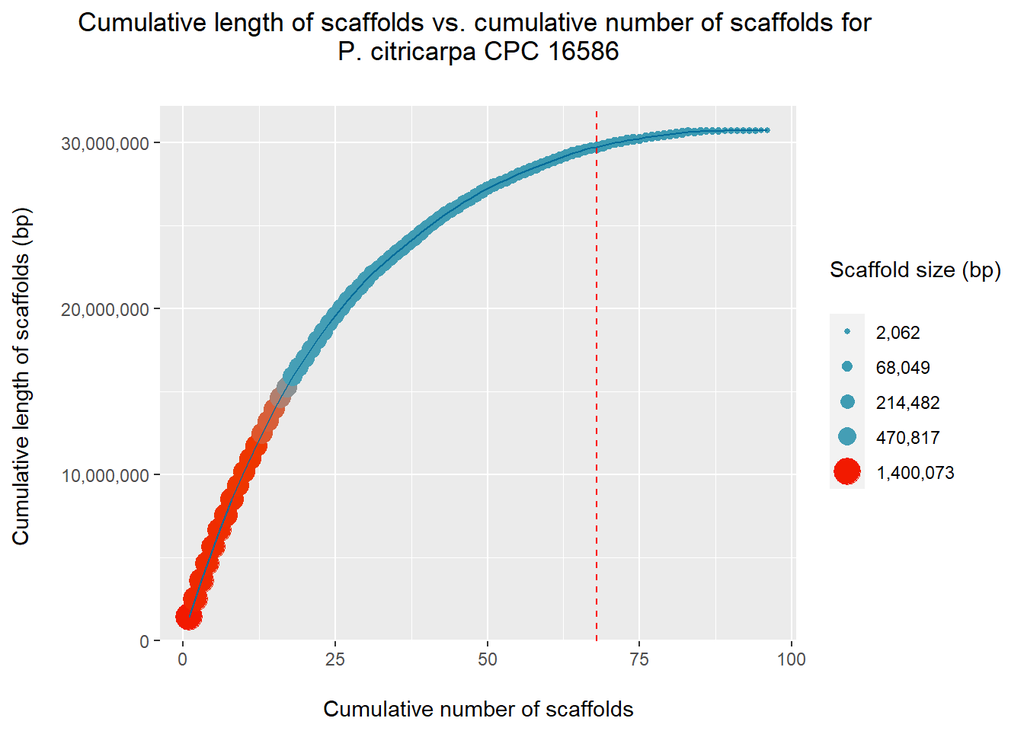

```r
PCitricarpa_CPC16586_final_plot
```

## *Phyllosticta citricarpa* CPC 27913

```r
# Read scaffold/contig lengths with read.fasta from seqinr
PCitricarpa_CPC27913_fasta <- read.fasta("PCitricarpa_CPC27913.fasta")
PCitricarpa_CPC27913_lengths <- getLength(PCitricarpa_CPC27913_fasta)

#Length sum, percentage of total length, cumulative sum
PCitricarpa_CPC27913_length_sum <- sum(PCitricarpa_CPC27913_lengths)
PCitricarpa_CPC27913_perc <- PCitricarpa_CPC27913_lengths/PCitricarpa_CPC27913_length_sum
PCitricarpa_CPC27913_length_cumsum <- cumsum(PCitricarpa_CPC27913_lengths)
PCitricarpa_CPC27913_perc_cumsum <- cumsum(PCitricarpa_CPC27913_perc)

#Creating a data frame for ggplot
PCitricarpa_CPC27913_df <- data.frame(PCitricarpa_CPC27913_lengths, PCitricarpa_CPC27913_perc)
```

Plotting cumulative sum of lengths and saving image

```r
# Adjusting colour palette according to number of contigs
PCitricarpa_CPC27913_colours <- c(wes_palette("Zissou1", length(PCitricarpa_CPC27913_lengths), type="continuous"))

PCitricarpa_CPC27913_length_title <- paste("Cumulative length of scaffolds vs. cumulative number of scaffolds for \n", "P. citricarpa CPC 27913 \n")

PCitricarpa_CPC27913_length_plot <-
  ggplot(PCitricarpa_CPC27913_df,
         aes(x=1:length(PCitricarpa_CPC27913_length_cumsum),
             y=PCitricarpa_CPC27913_length_cumsum)) +
  geom_point(aes(size=PCitricarpa_CPC27913_lengths, color = PCitricarpa_CPC27913_lengths)) +
  scale_size_continuous(name = "Scaffold size (bp)\n", breaks = fivenum(PCitricarpa_CPC27913_df$PCitricarpa_CPC27913_lengths), labels = comma(fivenum(PCitricarpa_CPC27913_df$PCitricarpa_CPC27913_lengths))) +
  geom_vline(xintercept=51, linetype="dashed", color = "red") +
  scale_color_continuous(low = head(PCitricarpa_CPC27913_colours), high = tail(PCitricarpa_CPC27913_colours), name = "Scaffold size (bp)\n", guide = "legend", breaks = fivenum(PCitricarpa_CPC27913_df$PCitricarpa_CPC27913_lengths), labels = comma(fivenum(PCitricarpa_CPC27913_df$PCitricarpa_CPC27913_lengths))) +
  geom_line(color="#046C9A")

## Final plot

PCitricarpa_CPC27913_final_plot <-
  PCitricarpa_CPC27913_length_plot +
  ggtitle(PCitricarpa_CPC27913_length_title) +
  xlab("\nCumulative number of scaffolds") +
  ylab("Cumulative length of scaffolds (bp) \n") +
  theme(plot.title = element_text(hjust = 0.5)) +
   scale_y_continuous(label=comma)

png("./PCitricarpa/PCitricarpa_CPC27913.png")
  PCitricarpa_CPC27913_final_plot
dev.off()
```

```r
pdf("./PCitricarpa/PCitricarpa_CPC27913.pdf")
  PCitricarpa_CPC27913_final_plot
dev.off()
```

```r
svg("./PCitricarpa/PCitricarpa_CPC27913.svg")
  PCitricarpa_CPC27913_final_plot
dev.off()
```

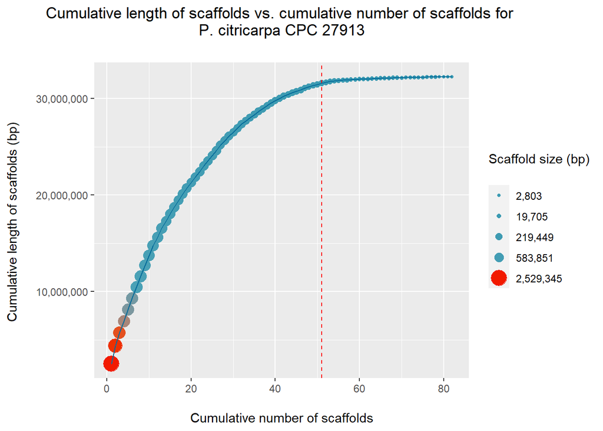

```r
PCitricarpa_CPC27913_final_plot
```

# *Phyllosticta citrichinaensis*

```r
dir.create("PCitrichinaensis")
```

## *Phyllosticta citrichinaensis* CBS 129764

Reading data

```r
# Read scaffold/contig lengths with read.fasta from seqinr
PCitrichinaensis_CBS129764_fasta <- read.fasta("PCitrichinaensis_CBS129764.fasta")
PCitrichinaensis_CBS129764_lengths <- getLength(PCitrichinaensis_CBS129764_fasta)

#Length sum, percentage of total length, cumulative sum
PCitrichinaensis_CBS129764_length_sum <- sum(PCitrichinaensis_CBS129764_lengths)
PCitrichinaensis_CBS129764_perc <- PCitrichinaensis_CBS129764_lengths/PCitrichinaensis_CBS129764_length_sum
PCitrichinaensis_CBS129764_length_cumsum <- cumsum(PCitrichinaensis_CBS129764_lengths)
PCitrichinaensis_CBS129764_perc_cumsum <- cumsum(PCitrichinaensis_CBS129764_perc)

#Creating a data frame for ggplot
PCitrichinaensis_CBS129764_df <- data.frame(PCitrichinaensis_CBS129764_lengths, PCitrichinaensis_CBS129764_perc)
```

Plotting cumulative sum of lengths and saving image

```r
# Adjusting colour palette according to number of contigs
PCitrichinaensis_CBS129764_colours <- c(wes_palette("Zissou1", length(PCitrichinaensis_CBS129764_lengths), type="continuous"))

PCitrichinaensis_CBS129764_length_title <- paste("Cumulative length of scaffolds vs. cumulative number of scaffolds for \n", "P. citrichinaensis CBS 129764 \n")

PCitrichinaensis_CBS129764_length_plot <-
  ggplot(PCitrichinaensis_CBS129764_df,
         aes(x=1:length(PCitrichinaensis_CBS129764_length_cumsum),
             y=PCitrichinaensis_CBS129764_length_cumsum)) +
  geom_point(aes(size=PCitrichinaensis_CBS129764_lengths, color = PCitrichinaensis_CBS129764_lengths)) +
  scale_size_continuous(name = "Scaffold size (bp)\n", breaks = fivenum(PCitrichinaensis_CBS129764_df$PCitrichinaensis_CBS129764_lengths), labels = comma(fivenum(PCitrichinaensis_CBS129764_df$PCitrichinaensis_CBS129764_lengths))) +
  geom_vline(xintercept=18, linetype="dashed", color = "red") +
  scale_color_continuous(low = head(PCitrichinaensis_CBS129764_colours), high = tail(PCitrichinaensis_CBS129764_colours), name = "Scaffold size (bp)\n", guide = "legend", breaks = fivenum(PCitrichinaensis_CBS129764_df$PCitrichinaensis_CBS129764_lengths), labels = comma(fivenum(PCitrichinaensis_CBS129764_df$PCitrichinaensis_CBS129764_lengths))) + geom_line(color="#046C9A")

## Final plot

PCitrichinaensis_CBS129764_final_plot <-
  PCitrichinaensis_CBS129764_length_plot +
  ggtitle(PCitrichinaensis_CBS129764_length_title) +
  xlab("\nCumulative number of scaffolds") +
  ylab("Cumulative length of scaffolds (bp) \n") +
  theme(plot.title = element_text(hjust = 0.5)) +
   scale_y_continuous(label=comma)

png("./PCitrichinaensis/PCitrichinaensis_CBS129764.png")
  PCitrichinaensis_CBS129764_final_plot
dev.off()
```

```r
pdf("./PCitrichinaensis/PCitrichinaensis_CBS129764.pdf")
  PCitrichinaensis_CBS129764_final_plot
dev.off()
```

```r
svg("./PCitrichinaensis/PCitrichinaensis_CBS129764.svg")
  PCitrichinaensis_CBS129764_final_plot
dev.off()
```

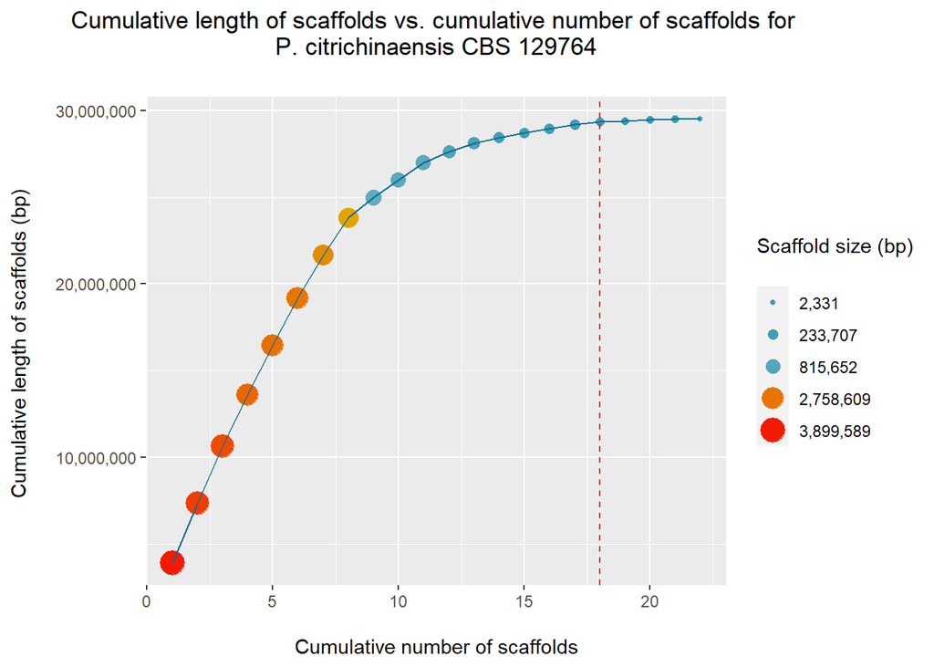

```r
PCitrichinaensis_CBS129764_final_plot
```

## *Phyllosticta citrichinaensis* CBS 130529

Reading data

```r
# Read scaffold/contig lengths with read.fasta from seqinr
PCitrichinaensis_CBS130529_fasta <- read.fasta("PCitrichinaensis_CBS130529.fasta")
PCitrichinaensis_CBS130529_lengths <- getLength(PCitrichinaensis_CBS130529_fasta)

#Length sum, percentage of total length, cumulative sum
PCitrichinaensis_CBS130529_length_sum <- sum(PCitrichinaensis_CBS130529_lengths)
PCitrichinaensis_CBS130529_perc <- PCitrichinaensis_CBS130529_lengths/PCitrichinaensis_CBS130529_length_sum
PCitrichinaensis_CBS130529_length_cumsum <- cumsum(PCitrichinaensis_CBS130529_lengths)
PCitrichinaensis_CBS130529_perc_cumsum <- cumsum(PCitrichinaensis_CBS130529_perc)

#Creating a data frame for ggplot
PCitrichinaensis_CBS130529_df <- data.frame(PCitrichinaensis_CBS130529_lengths, PCitrichinaensis_CBS130529_perc)
```

Plotting cumulative sum of lengths and saving image

```r
# Adjusting colour palette according to number of contigs
PCitrichinaensis_CBS130529_colours <- c(wes_palette("Zissou1", length(PCitrichinaensis_CBS130529_lengths), type="continuous"))

PCitrichinaensis_CBS130529_length_title <- paste("Cumulative length of scaffolds vs. cumulative number of scaffolds for \n", "P. citrichinaensis CBS 130529 \n")

PCitrichinaensis_CBS130529_length_plot <-
  ggplot(PCitrichinaensis_CBS130529_df,
         aes(x=1:length(PCitrichinaensis_CBS130529_length_cumsum),
             y=PCitrichinaensis_CBS130529_length_cumsum)) +
  geom_point(aes(size=PCitrichinaensis_CBS130529_lengths, color = PCitrichinaensis_CBS130529_lengths)) +
  scale_size_continuous(name = "Scaffold size (bp)\n", breaks = fivenum(PCitrichinaensis_CBS130529_df$PCitrichinaensis_CBS130529_lengths), labels = comma(fivenum(PCitrichinaensis_CBS130529_df$PCitrichinaensis_CBS130529_lengths))) +
  geom_vline(xintercept=19, linetype="dashed", color = "red") +
  scale_color_continuous(low = head(PCitrichinaensis_CBS130529_colours), high = tail(PCitrichinaensis_CBS130529_colours), name = "Scaffold size (bp)\n", guide = "legend", breaks = fivenum(PCitrichinaensis_CBS130529_df$PCitrichinaensis_CBS130529_lengths), labels = comma(fivenum(PCitrichinaensis_CBS130529_df$PCitrichinaensis_CBS130529_lengths))) + geom_line(color="#046C9A")

## Final plot

PCitrichinaensis_CBS130529_final_plot <-
  PCitrichinaensis_CBS130529_length_plot +
  ggtitle(PCitrichinaensis_CBS130529_length_title) +
  xlab("\nCumulative number of scaffolds") +
  ylab("Cumulative length of scaffolds (bp) \n") +
  theme(plot.title = element_text(hjust = 0.5)) +
   scale_y_continuous(label=comma)

png("./PCitrichinaensis/PCitrichinaensis_CBS130529.png")
  PCitrichinaensis_CBS130529_final_plot
dev.off()
```

```r
pdf("./PCitrichinaensis/PCitrichinaensis_CBS130529.pdf")
  PCitrichinaensis_CBS130529_final_plot
dev.off()
```

```r
svg("./PCitrichinaensis/PCitrichinaensis_CBS130529.svg")
  PCitrichinaensis_CBS130529_final_plot
dev.off()
```

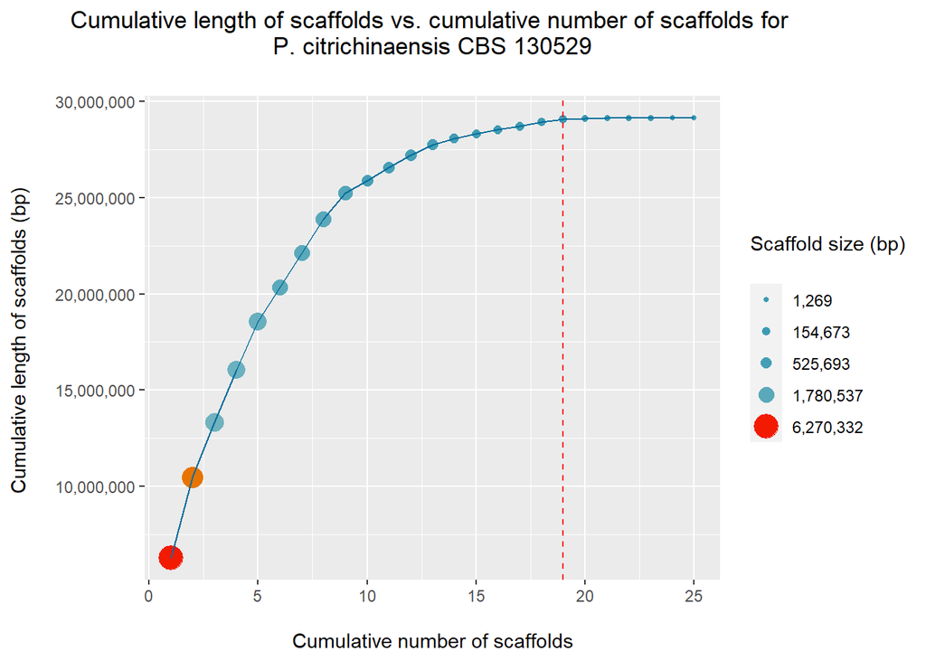

```r
PCitrichinaensis_CBS130529_final_plot
```

# *Phyllosticta paracitricarpa*

```r
dir.create("PParacitricarpa")
```

## *Phyllosticta paracitricarpa* CPC 27169

Reading data

```r
# Read scaffold/contig lengths with read.fasta from seqinr
PParacitricarpa_CPC27169_fasta <- read.fasta("PParacitricarpa_CPC27169.fasta")
PParacitricarpa_CPC27169_lengths <- getLength(PParacitricarpa_CPC27169_fasta)

#Length sum, percentage of total length, cumulative sum
PParacitricarpa_CPC27169_length_sum <- sum(PParacitricarpa_CPC27169_lengths)
PParacitricarpa_CPC27169_perc <- PParacitricarpa_CPC27169_lengths/PParacitricarpa_CPC27169_length_sum
PParacitricarpa_CPC27169_length_cumsum <- cumsum(PParacitricarpa_CPC27169_lengths)
PParacitricarpa_CPC27169_perc_cumsum <- cumsum(PParacitricarpa_CPC27169_perc)

#Creating a data frame for ggplot
PParacitricarpa_CPC27169_df <- data.frame(PParacitricarpa_CPC27169_lengths, PParacitricarpa_CPC27169_perc)
```

Plotting cumulative sum of lengths and saving image

```r
# Adjusting colour palette according to number of contigs
PParacitricarpa_CPC27169_colours <- c(wes_palette("Zissou1", length(PParacitricarpa_CPC27169_lengths), type="continuous"))

PParacitricarpa_CPC27169_length_title <- paste("Cumulative length of scaffolds vs. cumulative number of scaffolds for \n", "P. paracitricarpa CPC 27169 \n")

PParacitricarpa_CPC27169_length_plot <-
  ggplot(PParacitricarpa_CPC27169_df,
         aes(x=1:length(PParacitricarpa_CPC27169_length_cumsum),
             y=PParacitricarpa_CPC27169_length_cumsum)) +
  geom_point(aes(size=PParacitricarpa_CPC27169_lengths, color = PParacitricarpa_CPC27169_lengths)) +
  scale_size_continuous(name = "Scaffold size (bp)\n", breaks = fivenum(PParacitricarpa_CPC27169_df$PParacitricarpa_CPC27169_lengths), labels = comma(fivenum(PParacitricarpa_CPC27169_df$PParacitricarpa_CPC27169_lengths))) +
  geom_vline(xintercept=74, linetype="dashed", color = "red") +
  scale_color_continuous(low = head(PParacitricarpa_CPC27169_colours), high = tail(PParacitricarpa_CPC27169_colours), name = "Scaffold size (bp)\n", guide = "legend", breaks = fivenum(PParacitricarpa_CPC27169_df$PParacitricarpa_CPC27169_lengths), labels = comma(fivenum(PParacitricarpa_CPC27169_df$PParacitricarpa_CPC27169_lengths))) + geom_line(color="#046C9A")

## Final plot

PParacitricarpa_CPC27169_final_plot <-
  PParacitricarpa_CPC27169_length_plot +
  ggtitle(PParacitricarpa_CPC27169_length_title) +
  xlab("\nCumulative number of scaffolds") +
  ylab("Cumulative length of scaffolds (bp) \n") +
  theme(plot.title = element_text(hjust = 0.5)) +
   scale_y_continuous(label=comma)

png("./PParacitricarpa/PParacitricarpa_CPC27169.png")
  PParacitricarpa_CPC27169_final_plot
dev.off()
```

```r
pdf("./PParacitricarpa/PParacitricarpa_CPC27169.pdf")
  PParacitricarpa_CPC27169_final_plot
dev.off()
```

```r
svg("./PParacitricarpa/PParacitricarpa_CPC27169.svg")
  PParacitricarpa_CPC27169_final_plot
dev.off()
```

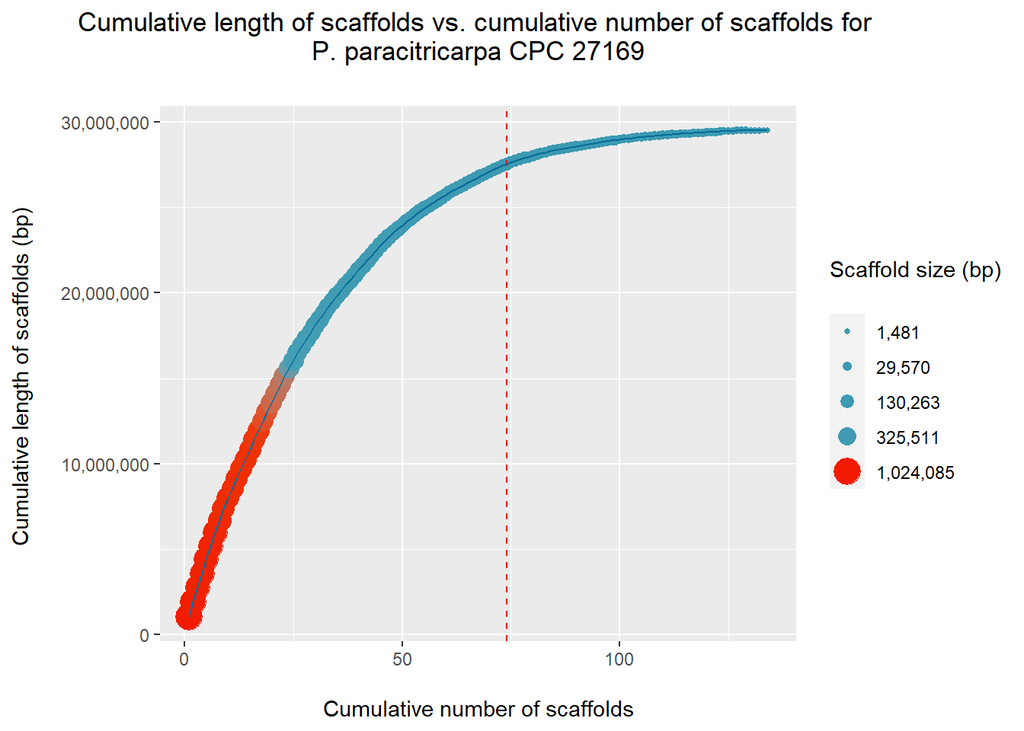

```r
PParacitricarpa_CPC27169_final_plot
```

## *Phyllosticta paracitricarpa* CBS 141358

Reading data

```r
# Read scaffold/contig lengths with read.fasta from seqinr
PParacitricarpa_CBS141358_fasta <- read.fasta("PParacitricarpa_CBS141358.fasta")
PParacitricarpa_CBS141358_lengths <- getLength(PParacitricarpa_CBS141358_fasta)

#Length sum, percentage of total length, cumulative sum
PParacitricarpa_CBS141358_length_sum <- sum(PParacitricarpa_CBS141358_lengths)
PParacitricarpa_CBS141358_perc <- PParacitricarpa_CBS141358_lengths/PParacitricarpa_CBS141358_length_sum
PParacitricarpa_CBS141358_length_cumsum <- cumsum(PParacitricarpa_CBS141358_lengths)
PParacitricarpa_CBS141358_perc_cumsum <- cumsum(PParacitricarpa_CBS141358_perc)

#Creating a data frame for ggplot
PParacitricarpa_CBS141358_df <- data.frame(PParacitricarpa_CBS141358_lengths, PParacitricarpa_CBS141358_perc)
```

Plotting cumulative sum of lengths and saving image

```r
# Adjusting colour palette according to number of contigs
PParacitricarpa_CBS141358_colours <- c(wes_palette("Zissou1", length(PParacitricarpa_CBS141358_lengths), type="continuous"))

PParacitricarpa_CBS141358_length_title <- paste("Cumulative length of scaffolds vs. cumulative number of scaffolds for \n", "P. paracitricarpa CBS 141358 \n")

PParacitricarpa_CBS141358_length_plot <-
  ggplot(PParacitricarpa_CBS141358_df,
         aes(x=1:length(PParacitricarpa_CBS141358_length_cumsum),
             y=PParacitricarpa_CBS141358_length_cumsum)) +
  geom_point(aes(size=PParacitricarpa_CBS141358_lengths, color = PParacitricarpa_CBS141358_lengths)) +
  scale_size_continuous(name = "Scaffold size (bp)\n", breaks = fivenum(PParacitricarpa_CBS141358_df$PParacitricarpa_CBS141358_lengths), labels = comma(fivenum(PParacitricarpa_CBS141358_df$PParacitricarpa_CBS141358_lengths))) +
  geom_vline(xintercept=65, linetype="dashed", color = "red") +
  scale_color_continuous(low = head(PParacitricarpa_CBS141358_colours), high = tail(PParacitricarpa_CBS141358_colours), name = "Scaffold size (bp)\n", guide = "legend", breaks = fivenum(PParacitricarpa_CBS141358_df$PParacitricarpa_CBS141358_lengths), labels = comma(fivenum(PParacitricarpa_CBS141358_df$PParacitricarpa_CBS141358_lengths))) + geom_line(color="#046C9A")

## Final plot

PParacitricarpa_CBS141358_final_plot <-
  PParacitricarpa_CBS141358_length_plot +
  ggtitle(PParacitricarpa_CBS141358_length_title) +
  xlab("\nCumulative number of scaffolds") +
  ylab("Cumulative length of scaffolds (bp) \n") +
  theme(plot.title = element_text(hjust = 0.5)) +
   scale_y_continuous(label=comma)

png("./PParacitricarpa/PParacitricarpa_CBS141358.png")
  PParacitricarpa_CBS141358_final_plot
dev.off()
```

```r
pdf("./PParacitricarpa/PParacitricarpa_CBS141358.pdf")
  PParacitricarpa_CBS141358_final_plot
dev.off()
```

```r
svg("./PParacitricarpa/PParacitricarpa_CBS141358.svg")
  PParacitricarpa_CBS141358_final_plot
dev.off()
```

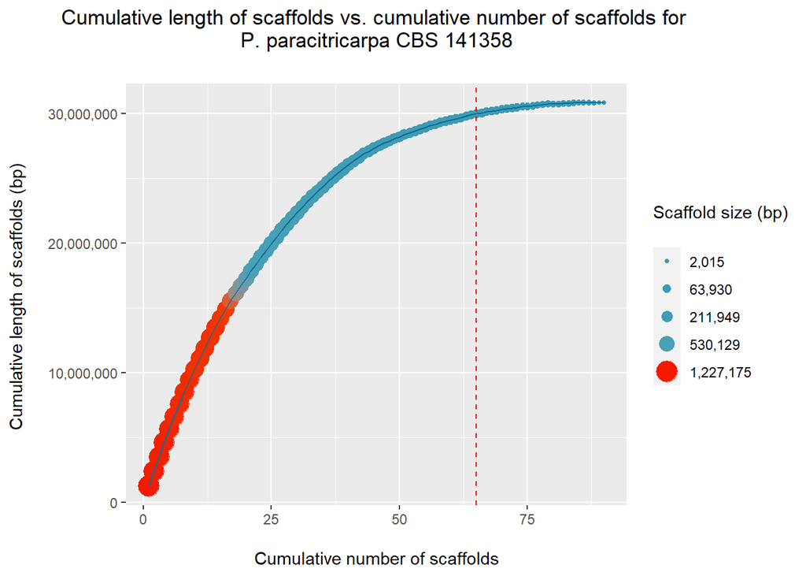

```r
PParacitricarpa_CBS141358_final_plot
```